# DV8week

```python
import pandas as pd
import numpy as np
import pandas_profiling
from plotnine import *
```

## df:새로운 열의 할당 2단계 (연쇄 할당)

`-` 모티브: 원본의 데이터를 가급적 손상시키지 않으면서 데이터를 변형하고 싶음

```python
df= pd.DataFrame({'A':range(0,5),'B':range(1,6)})
df
```

|  | A | B |
| --- | --- | --- |
| 0 | 0 | 1 |
| 1 | 1 | 2 |
| 2 | 2 | 3 |
| 3 | 3 | 4 |
| 4 | 4 | 5 |

복사

```python
df2 = df
df2
```

|  | A | B |
| --- | --- | --- |
| 0 | 0 | 1 |
| 1 | 1 | 2 |
| 2 | 2 | 3 |
| 3 | 3 | 4 |
| 4 | 4 | 5 |

```python
df2['C'] = (df2.A + df2.B)/2
df2
```

|  | A | B | C |
| --- | --- | --- | --- |
| 0 | 0 | 1 | 0.5 |
| 1 | 1 | 2 | 1.5 |
| 2 | 2 | 3 | 2.5 |
| 3 | 3 | 4 | 3.5 |
| 4 | 4 | 5 | 4.5 |

## 문제 상황 발생

```python
df
```

|  | A | B | C |
| --- | --- | --- | --- |
| 0 | 0 | 1 | 0.5 |
| 1 | 1 | 2 | 1.5 |
| 2 | 2 | 3 | 2.5 |
| 3 | 3 | 4 | 3.5 |
| 4 | 4 | 5 | 4.5 |

!!!! shallow copy 와 deep copy 에 의한 현상

## 해결책1 : df.copy 와 .eval 사용

### 올바른 코드1

```python
df= pd.DataFrame({'A':range(0,5),'B':range(1,6)})
df2= df.copy()
df2['C'] = (df2.A + df2.B)/2
df2['D'] = (df2.C - np.mean(df2.C))/np.std(df2.C)
```

```python
df2
```

|  | A | B | C | D |
| --- | --- | --- | --- | --- |
| 0 | 0 | 1 | 0.5 | -1.414214 |
| 1 | 1 | 2 | 1.5 | -0.707107 |
| 2 | 2 | 3 | 2.5 | 0.000000 |
| 3 | 3 | 4 | 3.5 | 0.707107 |
| 4 | 4 | 5 | 4.5 | 1.414214 |

```python
df #문제 없음
```

|  | A | B |
| --- | --- | --- |
| 0 | 0 | 1 |
| 1 | 1 | 2 |
| 2 | 2 | 3 |
| 3 | 3 | 4 |
| 4 | 4 | 5 |

### 올바른 코드2

```python
df= pd.DataFrame({'A':range(0,5),'B':range(1,6)})
mean = np.mean
std = np.std
df.eval('C=(A+B)/2').eval('D=(C-@mean(C))/@std(C)')
```

|  | A | B | C | D |
| --- | --- | --- | --- | --- |
| 0 | 0 | 1 | 0.5 | -1.414214 |
| 1 | 1 | 2 | 1.5 | -0.707107 |
| 2 | 2 | 3 | 2.5 | 0.000000 |
| 3 | 3 | 4 | 3.5 | 0.707107 |
| 4 | 4 | 5 | 4.5 | 1.414214 |

### 올바른 코드3 : 살패

```python
df = pd.DataFrame({'A':range(0,5),'B':range(1,6)})
df.assign(C= (df.A + df.B)/2)
```

|  | A | B | C |
| --- | --- | --- | --- |
| 0 | 0 | 1 | 0.5 |
| 1 | 1 | 2 | 1.5 |
| 2 | 2 | 3 | 2.5 |
| 3 | 3 | 4 | 3.5 |
| 4 | 4 | 5 | 4.5 |

```python
df.assign(C= (df.A + df.B)/2).assign(D= (df.C - np.mean(df.C))/np.std(df.C))
```

```
---------------------------------------------------------------------------
AttributeError                            Traceback (most recent call last)
Input In [25], in <cell line: 1>()
----> 1 df.assign(C= (df.A + df.B)/2).assign(D= (df.C - np.mean(df.C))/np.std(df.C))

File ~\anaconda3\envs\py39\lib\site-packages\pandas\core\generic.py:5575, in NDFrame.__getattr__(self, name)
   5568 if (
   5569     name not in self._internal_names_set
   5570     and name not in self._metadata
   5571     and name not in self._accessors
   5572     and self._info_axis._can_hold_identifiers_and_holds_name(name)
   5573 ):
   5574     return self[name]
-> 5575 return object.__getattribute__(self, name)

AttributeError: 'DataFrame' object has no attribute 'C'
```

```python
_df = df.assign(C= (df.A + df.B)/2)
_df.assign(D=(_df.C- np.mean(_df.C))/np.std(_df.C))
```

|  | A | B | C | D |
| --- | --- | --- | --- | --- |
| 0 | 0 | 1 | 0.5 | -1.414214 |
| 1 | 1 | 2 | 1.5 | -0.707107 |
| 2 | 2 | 3 | 2.5 | 0.000000 |
| 3 | 3 | 4 | 3.5 | 0.707107 |
| 4 | 4 | 5 | 4.5 | 1.414214 |

`*` 번거롭다

## 해결책 2 : assign 을 이용한 연쇄할당

```python
df.assign(C= (df.A + df.B)/2).assign(D= (df.C - np.mean(df.C))/np.std(df.C)) #실패한 코드
```

```
---------------------------------------------------------------------------
AttributeError                            Traceback (most recent call last)
Input In [29], in <cell line: 1>()
----> 1 df.assign(C= (df.A + df.B)/2).assign(D= (df.C - np.mean(df.C))/np.std(df.C))

File ~\anaconda3\envs\py39\lib\site-packages\pandas\core\generic.py:5575, in NDFrame.__getattr__(self, name)
   5568 if (
   5569     name not in self._internal_names_set
   5570     and name not in self._metadata
   5571     and name not in self._accessors
   5572     and self._info_axis._can_hold_identifiers_and_holds_name(name)
   5573 ):
   5574     return self[name]
-> 5575 return object.__getattribute__(self, name)

AttributeError: 'DataFrame' object has no attribute 'C'
```

`*` 우리의 목표: 두번째 assign에서 앞에서 C까지 할당된 df 를 받고 싶었는데 실패했다

### 올바른 방법: lambda

```python
df.assign(C= (df.A + df.B)/2).assign(D= lambda df : (df.C - np.mean(df.C))/np.std(df.C))
```

|  | A | B | C | D |
| --- | --- | --- | --- | --- |
| 0 | 0 | 1 | 0.5 | -1.414214 |
| 1 | 1 | 2 | 1.5 | -0.707107 |
| 2 | 2 | 3 | 2.5 | 0.000000 |
| 3 | 3 | 4 | 3.5 | 0.707107 |
| 4 | 4 | 5 | 4.5 | 1.414214 |

`-` 연쇄 할당 플러스 알파

```python
df.assign(C= (df.A + df.B)/2).assign(D= lambda df : (df.C - np.mean(df.C))/np.std(df.C)).assign(E = lambda df: df.D-2)
```

|  | A | B | C | D | E |
| --- | --- | --- | --- | --- | --- |
| 0 | 0 | 1 | 0.5 | -1.414214 | -3.414214 |
| 1 | 1 | 2 | 1.5 | -0.707107 | -2.707107 |
| 2 | 2 | 3 | 2.5 | 0.000000 | -2.000000 |
| 3 | 3 | 4 | 3.5 | 0.707107 | -1.292893 |
| 4 | 4 | 5 | 4.5 | 1.414214 | -0.585786 |

# FIFA 데이터 살펴보기

```python
df=pd.read_csv('https://raw.githubusercontent.com/guebin/2021DV/master/_notebooks/2021-10-25-FIFA22_official_data.csv')
```

```python
df
```

|  | ID | Name | Age | Photo | Nationality | Flag | Overall | Potential | Club | Club Logo | ... | SlidingTackle | GKDiving | GKHandling | GKKicking | GKPositioning | GKReflexes | Best Position | Best Overall Rating | Release Clause | DefensiveAwareness |
| --- | --- | --- | --- | --- | --- | --- | --- | --- | --- | --- | --- | --- | --- | --- | --- | --- | --- | --- | --- | --- | --- |
| 0 | 212198 | Bruno Fernandes | 26 | https://cdn.sofifa.com/players/212/198/22_60.png | Portugal | https://cdn.sofifa.com/flags/pt.png | 88 | 89 | Manchester United | https://cdn.sofifa.com/teams/11/30.png | ... | 65.0 | 12.0 | 14.0 | 15.0 | 8.0 | 14.0 | CAM | 88.0 | €206.9M | 72.0 |
| 1 | 209658 | L. Goretzka | 26 | https://cdn.sofifa.com/players/209/658/22_60.png | Germany | https://cdn.sofifa.com/flags/de.png | 87 | 88 | FC Bayern München | https://cdn.sofifa.com/teams/21/30.png | ... | 77.0 | 13.0 | 8.0 | 15.0 | 11.0 | 9.0 | CM | 87.0 | €160.4M | 74.0 |
| 2 | 176580 | L. Suárez | 34 | https://cdn.sofifa.com/players/176/580/22_60.png | Uruguay | https://cdn.sofifa.com/flags/uy.png | 88 | 88 | Atlético de Madrid | https://cdn.sofifa.com/teams/240/30.png | ... | 38.0 | 27.0 | 25.0 | 31.0 | 33.0 | 37.0 | ST | 88.0 | €91.2M | 42.0 |
| 3 | 192985 | K. De Bruyne | 30 | https://cdn.sofifa.com/players/192/985/22_60.png | Belgium | https://cdn.sofifa.com/flags/be.png | 91 | 91 | Manchester City | https://cdn.sofifa.com/teams/10/30.png | ... | 53.0 | 15.0 | 13.0 | 5.0 | 10.0 | 13.0 | CM | 91.0 | €232.2M | 68.0 |
| 4 | 224334 | M. Acuña | 29 | https://cdn.sofifa.com/players/224/334/22_60.png | Argentina | https://cdn.sofifa.com/flags/ar.png | 84 | 84 | Sevilla FC | https://cdn.sofifa.com/teams/481/30.png | ... | 82.0 | 8.0 | 14.0 | 13.0 | 13.0 | 14.0 | LB | 84.0 | €77.7M | 80.0 |
| ... | ... | ... | ... | ... | ... | ... | ... | ... | ... | ... | ... | ... | ... | ... | ... | ... | ... | ... | ... | ... | ... |
| 16705 | 240558 | 18 L. Clayton | 17 | https://cdn.sofifa.com/players/240/558/18_60.png | England | https://cdn.sofifa.com/flags/gb-eng.png | 53 | 70 | Cheltenham Town | https://cdn.sofifa.com/teams/1936/30.png | ... | 12.0 | 55.0 | 54.0 | 52.0 | 50.0 | 59.0 | GK | 52.0 | €238K | NaN |
| 16706 | 262846 | �. Dobre | 20 | https://cdn.sofifa.com/players/262/846/22_60.png | Romania | https://cdn.sofifa.com/flags/ro.png | 53 | 63 | FC Academica Clinceni | https://cdn.sofifa.com/teams/113391/30.png | ... | 12.0 | 57.0 | 52.0 | 53.0 | 48.0 | 58.0 | GK | 53.0 | €279K | 5.0 |
| 16707 | 241317 | 21 Xue Qinghao | 19 | https://cdn.sofifa.com/players/241/317/21_60.png | China PR | https://cdn.sofifa.com/flags/cn.png | 47 | 60 | Shanghai Shenhua FC | https://cdn.sofifa.com/teams/110955/30.png | ... | 9.0 | 49.0 | 48.0 | 45.0 | 38.0 | 52.0 | GK | 47.0 | €223K | 21.0 |
| 16708 | 259646 | A. Shaikh | 18 | https://cdn.sofifa.com/players/259/646/22_60.png | India | https://cdn.sofifa.com/flags/in.png | 47 | 67 | ATK Mohun Bagan FC | https://cdn.sofifa.com/teams/113146/30.png | ... | 13.0 | 49.0 | 41.0 | 39.0 | 45.0 | 49.0 | GK | 47.0 | €259K | 7.0 |
| 16709 | 178453 | 07 A. Censori | 17 | https://cdn.sofifa.com/players/178/453/07_60.png | Italy | https://cdn.sofifa.com/flags/it.png | 28 | 38 | Arezzo | https://cdn.sofifa.com/teams/110907/30.png | ... | NaN | 7.0 | 1.0 | 36.0 | 6.0 | 9.0 | ST | 36.0 | NaN | NaN |

16710 rows × 65 columns

```python
df.T
```

|  | 0 | 1 | 2 | 3 | 4 | 5 | 6 | 7 | 8 | 9 | ... | 16700 | 16701 | 16702 | 16703 | 16704 | 16705 | 16706 | 16707 | 16708 | 16709 |
| --- | --- | --- | --- | --- | --- | --- | --- | --- | --- | --- | --- | --- | --- | --- | --- | --- | --- | --- | --- | --- | --- |
| ID | 212198 | 209658 | 176580 | 192985 | 224334 | 212622 | 187961 | 181291 | 208333 | 194765 | ... | 252115 | 263373 | 248214 | 259718 | 251433 | 240558 | 262846 | 241317 | 259646 | 178453 |
| Name | Bruno Fernandes | L. Goretzka | L. Suárez | K. De Bruyne | M. Acuña | J. Kimmich | Paulinho | G. Wijnaldum | E. Can | A. Griezmann | ... | 20 B. Machini | J. Searle | A. Poplevchenkov | F. Gebhardt | B. Voll | 18 L. Clayton | �. Dobre | 21 Xue Qinghao | A. Shaikh | 07 A. Censori |
| Age | 26 | 26 | 34 | 30 | 29 | 26 | 32 | 30 | 27 | 30 | ... | 22 | 20 | 21 | 19 | 20 | 17 | 20 | 19 | 18 | 17 |
| Photo | https://cdn.sofifa.com/players/212/198/22_60.png | https://cdn.sofifa.com/players/209/658/22_60.png | https://cdn.sofifa.com/players/176/580/22_60.png | https://cdn.sofifa.com/players/192/985/22_60.png | https://cdn.sofifa.com/players/224/334/22_60.png | https://cdn.sofifa.com/players/212/622/22_60.png | https://cdn.sofifa.com/players/187/961/22_60.png | https://cdn.sofifa.com/players/181/291/22_60.png | https://cdn.sofifa.com/players/208/333/22_60.png | https://cdn.sofifa.com/players/194/765/22_60.png | ... | https://cdn.sofifa.com/players/252/115/20_60.png | https://cdn.sofifa.com/players/263/373/22_60.png | https://cdn.sofifa.com/players/248/214/22_60.png | https://cdn.sofifa.com/players/259/718/22_60.png | https://cdn.sofifa.com/players/251/433/22_60.png | https://cdn.sofifa.com/players/240/558/18_60.png | https://cdn.sofifa.com/players/262/846/22_60.png | https://cdn.sofifa.com/players/241/317/21_60.png | https://cdn.sofifa.com/players/259/646/22_60.png | https://cdn.sofifa.com/players/178/453/07_60.png |
| Nationality | Portugal | Germany | Uruguay | Belgium | Argentina | Germany | Brazil | Netherlands | Germany | France | ... | United States | New Zealand | Russia | Germany | Germany | England | Romania | China PR | India | Italy |
| ... | ... | ... | ... | ... | ... | ... | ... | ... | ... | ... | ... | ... | ... | ... | ... | ... | ... | ... | ... | ... | ... |
| GKReflexes | 14.0 | 9.0 | 37.0 | 13.0 | 14.0 | 15.0 | 8.0 | 6.0 | 11.0 | 14.0 | ... | 55.0 | 50.0 | 57.0 | 57.0 | 61.0 | 59.0 | 58.0 | 52.0 | 49.0 | 9.0 |
| Best Position | CAM | CM | ST | CM | LB | CDM | CM | CM | CDM | CAM | ... | GK | GK | GK | GK | GK | GK | GK | GK | GK | ST |
| Best Overall Rating | 88.0 | 87.0 | 88.0 | 91.0 | 84.0 | 89.0 | 83.0 | 84.0 | 85.0 | 86.0 | ... | 51.0 | 51.0 | 52.0 | 52.0 | 58.0 | 52.0 | 53.0 | 47.0 | 47.0 | 36.0 |
| Release Clause | €206.9M | €160.4M | €91.2M | €232.2M | €77.7M | €186.3M | €48.5M | €74.9M | €62.1M | NaN | ... | €87K | €303K | €378K | €361K | €656K | €238K | €279K | €223K | €259K | NaN |
| DefensiveAwareness | 72.0 | 74.0 | 42.0 | 68.0 | 80.0 | 85.0 | 80.0 | 79.0 | 81.0 | 43.0 | ... | 13.0 | 7.0 | 6.0 | 6.0 | 5.0 | NaN | 5.0 | 21.0 | 7.0 | NaN |

65 rows × 16710 columns

#### 칼럼 이름 조사

```python
df.keys()
```

```
Index(['ID', 'Name', 'Age', 'Photo', 'Nationality', 'Flag', 'Overall',
       'Potential', 'Club', 'Club Logo', 'Value', 'Wage', 'Special',
       'Preferred Foot', 'International Reputation', 'Weak Foot',
       'Skill Moves', 'Work Rate', 'Body Type', 'Real Face', 'Position',
       'Jersey Number', 'Joined', 'Loaned From', 'Contract Valid Until',
       'Height', 'Weight', 'Crossing', 'Finishing', 'HeadingAccuracy',
       'ShortPassing', 'Volleys', 'Dribbling', 'Curve', 'FKAccuracy',
       'LongPassing', 'BallControl', 'Acceleration', 'SprintSpeed', 'Agility',
       'Reactions', 'Balance', 'ShotPower', 'Jumping', 'Stamina', 'Strength',
       'LongShots', 'Aggression', 'Interceptions', 'Positioning', 'Vision',
       'Penalties', 'Composure', 'Marking', 'StandingTackle', 'SlidingTackle',
       'GKDiving', 'GKHandling', 'GKKicking', 'GKPositioning', 'GKReflexes',
       'Best Position', 'Best Overall Rating', 'Release Clause',
       'DefensiveAwareness'],
      dtype='object')
```

`-` 이름에 스페이스가 있는것이 거슬림

`-` 각 칼럼 별로 자료형 조사

```python
pd.DataFrame({'colname':df.keys(), 'dtype':[df[key].dtype for key in df.keys()]})
```

|  | colname | dtype |
| --- | --- | --- |
| 0 | ID | int64 |
| 1 | Name | object |
| 2 | Age | int64 |
| 3 | Photo | object |
| 4 | Nationality | object |
| ... | ... | ... |
| 60 | GKReflexes | float64 |
| 61 | Best Position | object |
| 62 | Best Overall Rating | float64 |
| 63 | Release Clause | object |
| 64 | DefensiveAwareness | float64 |

65 rows × 2 columns

`-` 결측치 조사

```python
pd.DataFrame({'colname': df.keys(),
              'dtype':[df[key].dtype for key in df.keys()],
              'na':[df[key].isna().sum() for key in df.keys()]
             })
```

|  | colname | dtype | na |
| --- | --- | --- | --- |
| 0 | ID | int64 | 0 |
| 1 | Name | object | 0 |
| 2 | Age | int64 | 0 |
| 3 | Photo | object | 0 |
| 4 | Nationality | object | 0 |
| ... | ... | ... | ... |
| 60 | GKReflexes | float64 | 0 |
| 61 | Best Position | object | 0 |
| 62 | Best Overall Rating | float64 | 0 |
| 63 | Release Clause | object | 1749 |
| 64 | DefensiveAwareness | float64 | 892 |

65 rows × 3 columns

#### 결측치가 10000개 이상인 열을 보고싶다

```python
df.loc[:,[df[key].isna().sum() > 10000 for key in df.keys()]]
```

|  | Loaned From | Marking |
| --- | --- | --- |
| 0 | NaN | NaN |
| 1 | NaN | NaN |
| 2 | NaN | NaN |
| 3 | NaN | NaN |
| 4 | NaN | NaN |
| ... | ... | ... |
| 16705 | NaN | 5.0 |
| 16706 | NaN | NaN |
| 16707 | NaN | NaN |
| 16708 | NaN | NaN |
| 16709 | NaN | 15.0 |

16710 rows × 2 columns

#### .info()

```python
df.info() #내가 위에서 한 행동이 다 여기있다
```

```
<class 'pandas.core.frame.DataFrame'>
RangeIndex: 16710 entries, 0 to 16709
Data columns (total 65 columns):
 #   Column                    Non-Null Count  Dtype
---  ------                    --------------  -----
 0   ID                        16710 non-null  int64
 1   Name                      16710 non-null  object
 2   Age                       16710 non-null  int64
 3   Photo                     16710 non-null  object
 4   Nationality               16710 non-null  object
 5   Flag                      16710 non-null  object
 6   Overall                   16710 non-null  int64
 7   Potential                 16710 non-null  int64
 8   Club                      16446 non-null  object
 9   Club Logo                 16710 non-null  object
```

[output cut: 57 more lines]

#### .describe(): 숫자들이 저장된 열에 대해서 기초통계량 조사

```python
df.describe()
```

|  | ID | Age | Overall | Potential | Special | International Reputation | Weak Foot | Skill Moves | Jersey Number | Crossing | ... | Marking | StandingTackle | SlidingTackle | GKDiving | GKHandling | GKKicking | GKPositioning | GKReflexes | Best Overall Rating | DefensiveAwareness |
| --- | --- | --- | --- | --- | --- | --- | --- | --- | --- | --- | --- | --- | --- | --- | --- | --- | --- | --- | --- | --- | --- |
| count | 16710.000000 | 16710.000000 | 16710.000000 | 16710.000000 | 16710.000000 | 16710.000000 | 16710.000000 | 16710.000000 | 16684.000000 | 16710.000000 | ... | 892.000000 | 16710.000000 | 16673.000000 | 16710.000000 | 16710.000000 | 16710.000000 | 16710.000000 | 16710.000000 | 16710.000000 | 15818.000000 |
| mean | 220560.467923 | 25.727409 | 67.646320 | 72.572292 | 1652.497307 | 1.169958 | 3.008199 | 2.475464 | 20.458643 | 52.212448 | ... | 48.021300 | 49.155536 | 46.830564 | 15.683662 | 15.521364 | 15.457989 | 15.581927 | 15.789228 | 68.565410 | 48.019408 |
| std | 38496.607959 | 5.048910 | 6.457695 | 5.688085 | 257.271696 | 0.485305 | 0.681742 | 0.791414 | 17.699813 | 17.772348 | ... | 21.904204 | 21.454857 | 21.175431 | 17.009757 | 16.302298 | 16.099993 | 16.584045 | 17.318251 | 6.256253 | 20.181354 |
| min | 27.000000 | 16.000000 | 28.000000 | 38.000000 | 571.000000 | 1.000000 | 1.000000 | 1.000000 | 1.000000 | 7.000000 | ... | 4.000000 | 3.000000 | 6.000000 | 1.000000 | 1.000000 | 1.000000 | 1.000000 | 1.000000 | 36.000000 | 3.000000 |
| 25% | 203891.250000 | 22.000000 | 63.000000 | 69.000000 | 1525.000000 | 1.000000 | 3.000000 | 2.000000 | 8.000000 | 42.000000 | ... | 27.000000 | 29.000000 | 26.000000 | 8.000000 | 8.000000 | 8.000000 | 8.000000 | 8.000000 | 65.000000 | 30.000000 |
| 50% | 229253.000000 | 25.000000 | 68.000000 | 72.000000 | 1687.000000 | 1.000000 | 3.000000 | 2.000000 | 17.000000 | 57.000000 | ... | 53.000000 | 57.000000 | 54.000000 | 11.000000 | 11.000000 | 11.000000 | 11.000000 | 11.000000 | 68.000000 | 54.000000 |
| 75% | 245368.750000 | 29.000000 | 72.000000 | 76.000000 | 1826.000000 | 1.000000 | 3.000000 | 3.000000 | 27.000000 | 65.000000 | ... | 67.000000 | 67.000000 | 65.000000 | 14.000000 | 14.000000 | 14.000000 | 14.000000 | 14.000000 | 73.000000 | 65.000000 |
| max | 264704.000000 | 54.000000 | 93.000000 | 95.000000 | 2341.000000 | 5.000000 | 5.000000 | 5.000000 | 99.000000 | 94.000000 | ... | 94.000000 | 93.000000 | 95.000000 | 91.000000 | 92.000000 | 93.000000 | 93.000000 | 90.000000 | 93.000000 | 93.000000 |

8 rows × 45 columns

#### 특정 열을 중심으로 보기

```python
df.sort_values(by='Overall', ascending=False).reset_index()
```

|  | index | ID | Name | Age | Photo | Nationality | Flag | Overall | Potential | Club | ... | SlidingTackle | GKDiving | GKHandling | GKKicking | GKPositioning | GKReflexes | Best Position | Best Overall Rating | Release Clause | DefensiveAwareness |
| --- | --- | --- | --- | --- | --- | --- | --- | --- | --- | --- | --- | --- | --- | --- | --- | --- | --- | --- | --- | --- | --- |
| 0 | 29 | 158023 | L. Messi | 34 | https://cdn.sofifa.com/players/158/023/22_60.png | Argentina | https://cdn.sofifa.com/flags/ar.png | 93 | 93 | Paris Saint-Germain | ... | 24.0 | 6.0 | 11.0 | 15.0 | 14.0 | 8.0 | RW | 93.0 | €144.3M | 20.0 |
| 1 | 33 | 188545 | R. Lewandowski | 32 | https://cdn.sofifa.com/players/188/545/22_60.png | Poland | https://cdn.sofifa.com/flags/pl.png | 92 | 92 | FC Bayern München | ... | 19.0 | 15.0 | 6.0 | 12.0 | 8.0 | 10.0 | ST | 92.0 | €197.2M | 35.0 |
| 2 | 14244 | 200389 | J. Oblak | 28 | https://cdn.sofifa.com/players/200/389/22_60.png | Slovenia | https://cdn.sofifa.com/flags/si.png | 91 | 93 | Atlético de Madrid | ... | 18.0 | 87.0 | 92.0 | 78.0 | 90.0 | 90.0 | GK | 91.0 | €238M | 27.0 |
| 3 | 3 | 192985 | K. De Bruyne | 30 | https://cdn.sofifa.com/players/192/985/22_60.png | Belgium | https://cdn.sofifa.com/flags/be.png | 91 | 91 | Manchester City | ... | 53.0 | 15.0 | 13.0 | 5.0 | 10.0 | 13.0 | CM | 91.0 | €232.2M | 68.0 |
| 4 | 64 | 190871 | Neymar Jr | 29 | https://cdn.sofifa.com/players/190/871/22_60.png | Brazil | https://cdn.sofifa.com/flags/br.png | 91 | 91 | Paris Saint-Germain | ... | 29.0 | 9.0 | 9.0 | 15.0 | 15.0 | 11.0 | LW | 91.0 | €238.7M | 35.0 |
| ... | ... | ... | ... | ... | ... | ... | ... | ... | ... | ... | ... | ... | ... | ... | ... | ... | ... | ... | ... | ... | ... |
| 16705 | 15593 | 235352 | 18 T. Käßemodel | 28 | https://cdn.sofifa.com/players/235/352/18_60.png | Germany | https://cdn.sofifa.com/flags/de.png | 46 | 46 | FC Erzgebirge Aue | ... | 38.0 | 10.0 | 12.0 | 6.0 | 13.0 | 6.0 | CM | 45.0 | €47K | NaN |
| 16706 | 15685 | 219735 | 15 T. Fletcher | 19 | https://cdn.sofifa.com/players/219/735/15_60.png | England | https://cdn.sofifa.com/flags/gb-eng.png | 46 | 52 | Wycombe Wanderers | ... | 50.0 | 14.0 | 7.0 | 8.0 | 14.0 | 11.0 | CB | 46.0 | NaN | NaN |
| 16707 | 16572 | 19334 | 10 I. Baraclough | 38 | https://cdn.sofifa.com/players/019/334/10_60.png | England | https://cdn.sofifa.com/flags/gb-eng.png | 44 | 65 | NaN | ... | NaN | 5.0 | 20.0 | 46.0 | 20.0 | 20.0 | CM | 46.0 | NaN | NaN |
| 16708 | 15999 | 220806 | 16 E. Redman | 18 | https://cdn.sofifa.com/players/220/806/16_60.png | Wales | https://cdn.sofifa.com/flags/gb-wls.png | 44 | 57 | Newport County | ... | 38.0 | 13.0 | 7.0 | 16.0 | 9.0 | 7.0 | CB | 44.0 | NaN | NaN |
| 16709 | 16709 | 178453 | 07 A. Censori | 17 | https://cdn.sofifa.com/players/178/453/07_60.png | Italy | https://cdn.sofifa.com/flags/it.png | 28 | 38 | Arezzo | ... | NaN | 7.0 | 1.0 | 36.0 | 6.0 | 9.0 | ST | 36.0 | NaN | NaN |

16710 rows × 66 columns

### 특정 열을 그룹화 하여 보기

```python
df.Nationality.unique()
```

```
array(['Portugal', 'Germany', 'Uruguay', 'Belgium', 'Argentina', 'Brazil',
       'Netherlands', 'France', 'Croatia', 'Spain', 'Austria', 'Italy',
       'Colombia', 'Serbia', 'England', 'Chile', 'Poland', 'Egypt',
       'Denmark', "Côte d'Ivoire", 'Ukraine', 'Senegal', 'Morocco',
       'Wales', 'Ecuador', 'Mexico', 'Scotland', 'Ghana',
       'Czech Republic', 'Peru', 'Algeria', 'United States',
       'Bosnia and Herzegovina', 'Armenia', 'Korea Republic', 'Russia',
       'Slovakia', 'Central African Republic', 'Turkey',
       'North Macedonia', 'Romania', 'Jamaica', 'Canada', 'Nigeria',
       'Guinea', 'Switzerland', 'Mali', 'China PR', 'Norway', 'Sweden',
       'Zambia', 'Republic of Ireland', 'Australia', 'Benin', 'Israel',
       'Gabon', 'Angola', 'Montenegro', 'Paraguay', 'Iraq', 'Slovenia',
       'Cameroon', 'Iceland', 'Finland', 'Greece', 'Liberia', 'Congo DR',
       'Venezuela', 'Kosovo', 'Japan', 'Moldova', 'Honduras', 'Tunisia',
       'Bulgaria', 'Uzbekistan', 'Suriname', 'Curacao', 'Albania',
       'Hungary', 'Guinea Bissau', 'Costa Rica', 'Northern Ireland',
       'Fiji', 'Burkina Faso', 'Cape Verde Islands', 'Saudi Arabia',
       'Iran', 'Comoros', 'Dominican Republic', 'Kenya', 'Panama',
       'New Zealand', 'South Africa', 'Georgia', 'Zimbabwe', 'Madagascar',
       'Cyprus', 'Malta', 'Chinese Taipei', 'Syria', 'Mozambique', 'Cuba',
       'Equatorial Guinea', 'Kazakhstan', 'Congo', 'Burundi', 'Grenada',
       'Thailand', 'Togo', 'Luxembourg', 'Trinidad and Tobago',
       'Saint Kitts and Nevis', 'Libya', 'Tanzania', 'Liechtenstein',
       'United Arab Emirates', 'Gambia', 'Faroe Islands', 'Bermuda',
       'Sierra Leone', 'Rwanda', 'Chad', 'São Tomé e Príncipe', 'Uganda',
       'Philippines', 'Palestine', 'Montserrat', 'Bolivia',
       'Antigua and Barbuda', 'India', 'Lithuania', 'Jordan', 'Belize',
       'Guyana', 'Azerbaijan', 'Haiti', 'Mauritania', 'Guam', 'Belarus',
       'El Salvador', 'Puerto Rico', 'Afghanistan', 'Korea DPR', 'Niger',
       'Namibia', 'Estonia', 'Qatar', 'Eritrea', 'Kyrgyzstan', 'Barbados',
       'Sudan', 'Malaysia', 'Bhutan', 'Gibraltar', 'Mauritius',
       'Guatemala', 'New Caledonia', 'Saint Lucia', 'Papua New Guinea',
       'South Sudan', 'Andorra', 'Hong Kong', 'Lebanon', 'Latvia',
       'Vietnam', 'Indonesia', 'Macau', 'Oman'], dtype=object)
```

```python
df.groupby(by='Nationality')[['Overall']].agg({np.mean,len}).sort_values(('Overall','mean'),ascending=False)
```

| Nationality | Overall len | Overall mean |
| --- | --- | --- |
| Tanzania | 1 | 74.000000 |
| Mozambique | 4 | 72.750000 |
| Brazil | 819 | 72.411477 |
| Libya | 4 | 72.250000 |
| Fiji | 1 | 72.000000 |
| ... | ... | ... |
| Malaysia | 2 | 59.000000 |
| India | 74 | 56.918919 |
| South Sudan | 3 | 54.333333 |
| Indonesia | 2 | 53.500000 |
| Hong Kong | 2 | 53.000000 |

168 rows × 2 columns

```python
df.groupby(by='Nationality')[['Potential']].agg({len,np.mean}).sort_values(('Potential','mean'), ascending = False)
#.agg({np.mean,len}).sort_values(('Overall','mean'),ascending=False)
```

| Nationality | Potential mean | Potential len |
| --- | --- | --- |
| Namibia | 80.000000 | 1 |
| Qatar | 78.000000 | 1 |
| Ukraine | 76.492754 | 69 |
| Portugal | 75.545198 | 354 |
| Croatia | 75.271429 | 140 |
| ... | ... | ... |
| Belize | 63.000000 | 1 |
| India | 62.608108 | 74 |
| Barbados | 61.500000 | 2 |
| Lebanon | 61.000000 | 1 |
| Hong Kong | 59.000000 | 2 |

168 rows × 2 columns

#### 공부하다가 느낀점

공부하다가 느낀건데 sort_values(('Overall','mean')) 은 튜플로만 받는 것 같다

그리고 오버롤 처럼 밑에 mean이랑 len 을 거느리고 있는 상태에서 튜플로 받는 것임  
앞에 큰 틀 그리고 두번째에 하위 변수가 들어간다

## 데이터 정리하기

### 칼럼 이름 변경

```python
df.set_axis(pd.Index(map(lambda x: x.replace(' ','_'), df.columns)), axis= 1)
```

|  | ID | Name | Age | Photo | Nationality | Flag | Overall | Potential | Club | Club_Logo | ... | SlidingTackle | GKDiving | GKHandling | GKKicking | GKPositioning | GKReflexes | Best_Position | Best_Overall_Rating | Release_Clause | DefensiveAwareness |
| --- | --- | --- | --- | --- | --- | --- | --- | --- | --- | --- | --- | --- | --- | --- | --- | --- | --- | --- | --- | --- | --- |
| 0 | 212198 | Bruno Fernandes | 26 | https://cdn.sofifa.com/players/212/198/22_60.png | Portugal | https://cdn.sofifa.com/flags/pt.png | 88 | 89 | Manchester United | https://cdn.sofifa.com/teams/11/30.png | ... | 65.0 | 12.0 | 14.0 | 15.0 | 8.0 | 14.0 | CAM | 88.0 | €206.9M | 72.0 |
| 1 | 209658 | L. Goretzka | 26 | https://cdn.sofifa.com/players/209/658/22_60.png | Germany | https://cdn.sofifa.com/flags/de.png | 87 | 88 | FC Bayern München | https://cdn.sofifa.com/teams/21/30.png | ... | 77.0 | 13.0 | 8.0 | 15.0 | 11.0 | 9.0 | CM | 87.0 | €160.4M | 74.0 |
| 2 | 176580 | L. Suárez | 34 | https://cdn.sofifa.com/players/176/580/22_60.png | Uruguay | https://cdn.sofifa.com/flags/uy.png | 88 | 88 | Atlético de Madrid | https://cdn.sofifa.com/teams/240/30.png | ... | 38.0 | 27.0 | 25.0 | 31.0 | 33.0 | 37.0 | ST | 88.0 | €91.2M | 42.0 |
| 3 | 192985 | K. De Bruyne | 30 | https://cdn.sofifa.com/players/192/985/22_60.png | Belgium | https://cdn.sofifa.com/flags/be.png | 91 | 91 | Manchester City | https://cdn.sofifa.com/teams/10/30.png | ... | 53.0 | 15.0 | 13.0 | 5.0 | 10.0 | 13.0 | CM | 91.0 | €232.2M | 68.0 |
| 4 | 224334 | M. Acuña | 29 | https://cdn.sofifa.com/players/224/334/22_60.png | Argentina | https://cdn.sofifa.com/flags/ar.png | 84 | 84 | Sevilla FC | https://cdn.sofifa.com/teams/481/30.png | ... | 82.0 | 8.0 | 14.0 | 13.0 | 13.0 | 14.0 | LB | 84.0 | €77.7M | 80.0 |
| ... | ... | ... | ... | ... | ... | ... | ... | ... | ... | ... | ... | ... | ... | ... | ... | ... | ... | ... | ... | ... | ... |
| 16705 | 240558 | 18 L. Clayton | 17 | https://cdn.sofifa.com/players/240/558/18_60.png | England | https://cdn.sofifa.com/flags/gb-eng.png | 53 | 70 | Cheltenham Town | https://cdn.sofifa.com/teams/1936/30.png | ... | 12.0 | 55.0 | 54.0 | 52.0 | 50.0 | 59.0 | GK | 52.0 | €238K | NaN |
| 16706 | 262846 | �. Dobre | 20 | https://cdn.sofifa.com/players/262/846/22_60.png | Romania | https://cdn.sofifa.com/flags/ro.png | 53 | 63 | FC Academica Clinceni | https://cdn.sofifa.com/teams/113391/30.png | ... | 12.0 | 57.0 | 52.0 | 53.0 | 48.0 | 58.0 | GK | 53.0 | €279K | 5.0 |
| 16707 | 241317 | 21 Xue Qinghao | 19 | https://cdn.sofifa.com/players/241/317/21_60.png | China PR | https://cdn.sofifa.com/flags/cn.png | 47 | 60 | Shanghai Shenhua FC | https://cdn.sofifa.com/teams/110955/30.png | ... | 9.0 | 49.0 | 48.0 | 45.0 | 38.0 | 52.0 | GK | 47.0 | €223K | 21.0 |
| 16708 | 259646 | A. Shaikh | 18 | https://cdn.sofifa.com/players/259/646/22_60.png | India | https://cdn.sofifa.com/flags/in.png | 47 | 67 | ATK Mohun Bagan FC | https://cdn.sofifa.com/teams/113146/30.png | ... | 13.0 | 49.0 | 41.0 | 39.0 | 45.0 | 49.0 | GK | 47.0 | €259K | 7.0 |
| 16709 | 178453 | 07 A. Censori | 17 | https://cdn.sofifa.com/players/178/453/07_60.png | Italy | https://cdn.sofifa.com/flags/it.png | 28 | 38 | Arezzo | https://cdn.sofifa.com/teams/110907/30.png | ... | NaN | 7.0 | 1.0 | 36.0 | 6.0 | 9.0 | ST | 36.0 | NaN | NaN |

16710 rows × 65 columns

`*` set_index에서 축은 0은 인덱스 1은 변수 이름들이다

### 결측치 제거

```python
df.loc[:,[df[key].isna().sum() > 10000 for key in df.keys()]]
```

|  | Loaned From | Marking |
| --- | --- | --- |
| 0 | NaN | NaN |
| 1 | NaN | NaN |
| 2 | NaN | NaN |
| 3 | NaN | NaN |
| 4 | NaN | NaN |
| ... | ... | ... |
| 16705 | NaN | 5.0 |
| 16706 | NaN | NaN |
| 16707 | NaN | NaN |
| 16708 | NaN | NaN |
| 16709 | NaN | 15.0 |

16710 rows × 2 columns

```python
df.query('Potential == Overall').query('Overall > 85')
```

|  | ID | Name | Age | Photo | Nationality | Flag | Overall | Potential | Club | Club Logo | ... | SlidingTackle | GKDiving | GKHandling | GKKicking | GKPositioning | GKReflexes | Best Position | Best Overall Rating | Release Clause | DefensiveAwareness |
| --- | --- | --- | --- | --- | --- | --- | --- | --- | --- | --- | --- | --- | --- | --- | --- | --- | --- | --- | --- | --- | --- |
| 2 | 176580 | L. Suárez | 34 | https://cdn.sofifa.com/players/176/580/22_60.png | Uruguay | https://cdn.sofifa.com/flags/uy.png | 88 | 88 | Atlético de Madrid | https://cdn.sofifa.com/teams/240/30.png | ... | 38.0 | 27.0 | 25.0 | 31.0 | 33.0 | 37.0 | ST | 88.0 | €91.2M | 42.0 |
| 3 | 192985 | K. De Bruyne | 30 | https://cdn.sofifa.com/players/192/985/22_60.png | Belgium | https://cdn.sofifa.com/flags/be.png | 91 | 91 | Manchester City | https://cdn.sofifa.com/teams/10/30.png | ... | 53.0 | 15.0 | 13.0 | 5.0 | 10.0 | 13.0 | CM | 91.0 | €232.2M | 68.0 |
| 10 | 177003 | L. Modrić | 35 | https://cdn.sofifa.com/players/177/003/22_60.png | Croatia | https://cdn.sofifa.com/flags/hr.png | 87 | 87 | Real Madrid CF | https://cdn.sofifa.com/teams/243/30.png | ... | 71.0 | 13.0 | 9.0 | 7.0 | 14.0 | 9.0 | CM | 87.0 | €65.6M | 70.0 |
| 12 | 155862 | Sergio Ramos | 35 | https://cdn.sofifa.com/players/155/862/22_60.png | Spain | https://cdn.sofifa.com/flags/es.png | 88 | 88 | Paris Saint-Germain | https://cdn.sofifa.com/teams/73/30.png | ... | 91.0 | 11.0 | 8.0 | 9.0 | 7.0 | 11.0 | CB | 88.0 | €44.4M | 84.0 |
| 27 | 195864 | P. Pogba | 28 | https://cdn.sofifa.com/players/195/864/22_60.png | France | https://cdn.sofifa.com/flags/fr.png | 87 | 87 | Manchester United | https://cdn.sofifa.com/teams/11/30.png | ... | 63.0 | 5.0 | 6.0 | 2.0 | 4.0 | 3.0 | CM | 87.0 | €147.1M | 59.0 |
| 28 | 200145 | Casemiro | 29 | https://cdn.sofifa.com/players/200/145/22_60.png | Brazil | https://cdn.sofifa.com/flags/br.png | 89 | 89 | Real Madrid CF | https://cdn.sofifa.com/teams/243/30.png | ... | 87.0 | 13.0 | 14.0 | 16.0 | 12.0 | 12.0 | CDM | 89.0 | €180.4M | 85.0 |
| 29 | 158023 | L. Messi | 34 | https://cdn.sofifa.com/players/158/023/22_60.png | Argentina | https://cdn.sofifa.com/flags/ar.png | 93 | 93 | Paris Saint-Germain | https://cdn.sofifa.com/teams/73/30.png | ... | 24.0 | 6.0 | 11.0 | 15.0 | 14.0 | 8.0 | RW | 93.0 | €144.3M | 20.0 |
| 32 | 189332 | Jordi Alba | 32 | https://cdn.sofifa.com/players/189/332/22_60.png | Spain | https://cdn.sofifa.com/flags/es.png | 86 | 86 | FC Barcelona | https://cdn.sofifa.com/teams/241/30.png | ... | 80.0 | 13.0 | 15.0 | 13.0 | 6.0 | 13.0 | LB | 86.0 | €96.4M | 74.0 |
| 33 | 188545 | R. Lewandowski | 32 | https://cdn.sofifa.com/players/188/545/22_60.png | Poland | https://cdn.sofifa.com/flags/pl.png | 92 | 92 | FC Bayern München | https://cdn.sofifa.com/teams/21/30.png | ... | 19.0 | 15.0 | 6.0 | 12.0 | 8.0 | 10.0 | ST | 92.0 | €197.2M | 35.0 |
| 34 | 209331 | M. Salah | 29 | https://cdn.sofifa.com/players/209/331/22_60.png | Egypt | https://cdn.sofifa.com/flags/eg.png | 89 | 89 | Liverpool | https://cdn.sofifa.com/teams/9/30.png | ... | 41.0 | 14.0 | 14.0 | 9.0 | 11.0 | 14.0 | RW | 89.0 | €186.9M | 38.0 |
| 36 | 20801 | Cristiano Ronaldo | 36 | https://cdn.sofifa.com/players/020/801/22_60.png | Portugal | https://cdn.sofifa.com/flags/pt.png | 91 | 91 | Manchester United | https://cdn.sofifa.com/teams/11/30.png | ... | 24.0 | 7.0 | 11.0 | 15.0 | 14.0 | 11.0 | ST | 91.0 | €83.3M | 24.0 |
| 39 | 202126 | H. Kane | 27 | https://cdn.sofifa.com/players/202/126/22_60.png | England | https://cdn.sofifa.com/flags/gb-eng.png | 90 | 90 | Tottenham Hotspur | https://cdn.sofifa.com/teams/18/30.png | ... | 38.0 | 8.0 | 10.0 | 11.0 | 14.0 | 11.0 | ST | 90.0 | €246.1M | 50.0 |
| 42 | 199556 | M. Verratti | 28 | https://cdn.sofifa.com/players/199/556/22_60.png | Italy | https://cdn.sofifa.com/flags/it.png | 87 | 87 | Paris Saint-Germain | https://cdn.sofifa.com/teams/73/30.png | ... | 84.0 | 12.0 | 12.0 | 15.0 | 15.0 | 10.0 | CM | 87.0 | €147.1M | 78.0 |
| 44 | 189509 | Thiago | 30 | https://cdn.sofifa.com/players/189/509/22_60.png | Spain | https://cdn.sofifa.com/flags/es.png | 86 | 86 | Liverpool | https://cdn.sofifa.com/teams/9/30.png | ... | 68.0 | 6.0 | 11.0 | 7.0 | 9.0 | 13.0 | CM | 86.0 | €120.3M | 67.0 |
| 55 | 208722 | S. Mané | 29 | https://cdn.sofifa.com/players/208/722/22_60.png | Senegal | https://cdn.sofifa.com/flags/sn.png | 89 | 89 | Liverpool | https://cdn.sofifa.com/teams/9/30.png | ... | 38.0 | 10.0 | 10.0 | 15.0 | 7.0 | 14.0 | LW | 89.0 | €186.9M | 42.0 |
| 64 | 190871 | Neymar Jr | 29 | https://cdn.sofifa.com/players/190/871/22_60.png | Brazil | https://cdn.sofifa.com/flags/br.png | 91 | 91 | Paris Saint-Germain | https://cdn.sofifa.com/teams/73/30.png | ... | 29.0 | 9.0 | 9.0 | 15.0 | 15.0 | 11.0 | LW | 91.0 | €238.7M | 35.0 |
| 71 | 215914 | N. Kanté | 30 | https://cdn.sofifa.com/players/215/914/22_60.png | France | https://cdn.sofifa.com/flags/fr.png | 90 | 90 | Chelsea | https://cdn.sofifa.com/teams/5/30.png | ... | 86.0 | 15.0 | 12.0 | 10.0 | 7.0 | 10.0 | CDM | 90.0 | €185M | 90.0 |
| 76 | 183898 | A. Di María | 33 | https://cdn.sofifa.com/players/183/898/22_60.png | Argentina | https://cdn.sofifa.com/flags/ar.png | 87 | 87 | Paris Saint-Germain | https://cdn.sofifa.com/teams/73/30.png | ... | 52.0 | 10.0 | 7.0 | 11.0 | 12.0 | 11.0 | RW | 87.0 | €91.6M | 41.0 |
| 92 | 189513 | Parejo | 32 | https://cdn.sofifa.com/players/189/513/22_60.png | Spain | https://cdn.sofifa.com/flags/es.png | 86 | 86 | Villarreal CF | https://cdn.sofifa.com/teams/483/30.png | ... | 69.0 | 5.0 | 9.0 | 12.0 | 14.0 | 8.0 | CM | 86.0 | €112.4M | 70.0 |
| 116 | 182521 | T. Kroos | 31 | https://cdn.sofifa.com/players/182/521/22_60.png | Germany | https://cdn.sofifa.com/flags/de.png | 88 | 88 | Real Madrid CF | https://cdn.sofifa.com/teams/243/30.png | ... | 60.0 | 10.0 | 11.0 | 13.0 | 7.0 | 10.0 | CM | 88.0 | €153.8M | 71.0 |
| 125 | 121939 | 17 P. Lahm | 32 | https://cdn.sofifa.com/players/121/939/17_60.png | Germany | https://cdn.sofifa.com/flags/de.png | 88 | 88 | FC Bayern München | https://cdn.sofifa.com/teams/21/30.png | ... | 95.0 | 11.0 | 12.0 | 5.0 | 14.0 | 5.0 | RWB | 85.0 | NaN | NaN |
| 129 | 200104 | H. Son | 28 | https://cdn.sofifa.com/players/200/104/22_60.png | Korea Republic | https://cdn.sofifa.com/flags/kr.png | 89 | 89 | Tottenham Hotspur | https://cdn.sofifa.com/teams/18/30.png | ... | 33.0 | 11.0 | 13.0 | 13.0 | 6.0 | 10.0 | LM | 89.0 | €197.6M | 50.0 |
| 150 | 189596 | T. Müller | 31 | https://cdn.sofifa.com/players/189/596/22_60.png | Germany | https://cdn.sofifa.com/flags/de.png | 87 | 87 | FC Bayern München | https://cdn.sofifa.com/teams/21/30.png | ... | 46.0 | 6.0 | 7.0 | 11.0 | 14.0 | 14.0 | CAM | 87.0 | €108.9M | 47.0 |
| 154 | 208830 | J. Vardy | 34 | https://cdn.sofifa.com/players/208/830/22_60.png | England | https://cdn.sofifa.com/flags/gb-eng.png | 86 | 86 | Leicester City | https://cdn.sofifa.com/teams/95/30.png | ... | 54.0 | 15.0 | 14.0 | 7.0 | 15.0 | 11.0 | ST | 86.0 | €62.7M | 45.0 |
| 170 | 218667 | Bernardo Silva | 26 | https://cdn.sofifa.com/players/218/667/22_60.png | Portugal | https://cdn.sofifa.com/flags/pt.png | 86 | 86 | Manchester City | https://cdn.sofifa.com/teams/10/30.png | ... | 45.0 | 9.0 | 10.0 | 14.0 | 12.0 | 9.0 | CAM | 86.0 | €136.9M | 49.0 |
| 196 | 208093 | Gerard Moreno | 29 | https://cdn.sofifa.com/players/208/093/22_60.png | Spain | https://cdn.sofifa.com/flags/es.png | 86 | 86 | Villarreal CF | https://cdn.sofifa.com/teams/483/30.png | ... | 41.0 | 15.0 | 12.0 | 7.0 | 12.0 | 10.0 | ST | 86.0 | €142.8M | 44.0 |
| 201 | 165153 | K. Benzema | 33 | https://cdn.sofifa.com/players/165/153/22_60.png | France | https://cdn.sofifa.com/flags/fr.png | 89 | 89 | Real Madrid CF | https://cdn.sofifa.com/teams/243/30.png | ... | 18.0 | 13.0 | 11.0 | 5.0 | 5.0 | 7.0 | CF | 89.0 | €135.3M | 43.0 |
| 241 | 203376 | V. van Dijk | 29 | https://cdn.sofifa.com/players/203/376/22_60.png | Netherlands | https://cdn.sofifa.com/flags/nl.png | 89 | 89 | Liverpool | https://cdn.sofifa.com/teams/9/30.png | ... | 86.0 | 13.0 | 10.0 | 13.0 | 11.0 | 11.0 | CB | 89.0 | €159.1M | 92.0 |
| 244 | 10535 | 15 Xavi | 34 | https://cdn.sofifa.com/players/010/535/15_60.png | Spain | https://cdn.sofifa.com/flags/es.png | 86 | 86 | FC Barcelona | https://cdn.sofifa.com/teams/241/30.png | ... | 59.0 | 5.0 | 15.0 | 12.0 | 5.0 | 9.0 | CAM | 85.0 | NaN | NaN |
| 396 | 153079 | S. Agüero | 33 | https://cdn.sofifa.com/players/153/079/22_60.png | Argentina | https://cdn.sofifa.com/flags/ar.png | 87 | 87 | FC Barcelona | https://cdn.sofifa.com/teams/241/30.png | ... | 24.0 | 13.0 | 15.0 | 6.0 | 11.0 | 14.0 | ST | 87.0 | €104.6M | 30.0 |
| 417 | 192387 | C. Immobile | 31 | https://cdn.sofifa.com/players/192/387/22_60.png | Italy | https://cdn.sofifa.com/flags/it.png | 87 | 87 | Lazio | https://cdn.sofifa.com/teams/46/30.png | ... | 32.0 | 6.0 | 8.0 | 15.0 | 12.0 | 6.0 | ST | 87.0 | €114.8M | 34.0 |
| 425 | 192505 | R. Lukaku | 28 | https://cdn.sofifa.com/players/192/505/22_60.png | Belgium | https://cdn.sofifa.com/flags/be.png | 88 | 88 | Chelsea | https://cdn.sofifa.com/teams/5/30.png | ... | 30.0 | 8.0 | 15.0 | 14.0 | 7.0 | 10.0 | ST | 88.0 | €173M | 30.0 |
| 556 | 178603 | M. Hummels | 32 | https://cdn.sofifa.com/players/178/603/22_60.png | Germany | https://cdn.sofifa.com/flags/de.png | 86 | 86 | Borussia Dortmund | https://cdn.sofifa.com/teams/22/30.png | ... | 86.0 | 15.0 | 6.0 | 10.0 | 5.0 | 6.0 | CB | 86.0 | €74.8M | 90.0 |
| 606 | 204485 | R. Mahrez | 30 | https://cdn.sofifa.com/players/204/485/22_60.png | Algeria | https://cdn.sofifa.com/flags/dz.png | 86 | 86 | Manchester City | https://cdn.sofifa.com/teams/10/30.png | ... | 22.0 | 15.0 | 9.0 | 13.0 | 11.0 | 6.0 | RW | 86.0 | €121.2M | 45.0 |
| 691 | 198219 | L. Insigne | 30 | https://cdn.sofifa.com/players/198/219/22_60.png | Italy | https://cdn.sofifa.com/flags/it.png | 86 | 86 | Napoli | https://cdn.sofifa.com/teams/48/30.png | ... | 22.0 | 8.0 | 4.0 | 14.0 | 9.0 | 10.0 | LW | 86.0 | €111.4M | 53.0 |
| 804 | 189511 | Sergio Busquets | 32 | https://cdn.sofifa.com/players/189/511/22_60.png | Spain | https://cdn.sofifa.com/flags/es.png | 86 | 86 | FC Barcelona | https://cdn.sofifa.com/teams/241/30.png | ... | 81.0 | 5.0 | 8.0 | 13.0 | 9.0 | 13.0 | CDM | 86.0 | €92.3M | 84.0 |
| 3560 | 138956 | G. Chiellini | 36 | https://cdn.sofifa.com/players/138/956/22_60.png | Italy | https://cdn.sofifa.com/flags/it.png | 86 | 86 | Juventus | https://cdn.sofifa.com/teams/45/30.png | ... | 88.0 | 3.0 | 3.0 | 2.0 | 4.0 | 3.0 | CB | 86.0 | €19.8M | 93.0 |
| 7835 | 201024 | K. Koulibaly | 30 | https://cdn.sofifa.com/players/201/024/22_60.png | Senegal | https://cdn.sofifa.com/flags/sn.png | 86 | 86 | Napoli | https://cdn.sofifa.com/teams/48/30.png | ... | 86.0 | 7.0 | 11.0 | 7.0 | 13.0 | 5.0 | CB | 86.0 | €94.4M | 90.0 |
| 12350 | 167495 | M. Neuer | 35 | https://cdn.sofifa.com/players/167/495/22_60.png | Germany | https://cdn.sofifa.com/flags/de.png | 90 | 90 | FC Bayern München | https://cdn.sofifa.com/teams/21/30.png | ... | 11.0 | 88.0 | 88.0 | 91.0 | 89.0 | 88.0 | GK | 90.0 | €22.3M | 17.0 |
| 14087 | 193041 | K. Navas | 34 | https://cdn.sofifa.com/players/193/041/22_60.png | Costa Rica | https://cdn.sofifa.com/flags/cr.png | 88 | 88 | Paris Saint-Germain | https://cdn.sofifa.com/teams/73/30.png | ... | 14.0 | 89.0 | 84.0 | 75.0 | 87.0 | 89.0 | GK | 88.0 | €28.7M | 28.0 |
| 14644 | 167948 | H. Lloris | 34 | https://cdn.sofifa.com/players/167/948/22_60.png | France | https://cdn.sofifa.com/flags/fr.png | 87 | 87 | Tottenham Hotspur | https://cdn.sofifa.com/teams/18/30.png | ... | 18.0 | 88.0 | 83.0 | 65.0 | 84.0 | 90.0 | GK | 87.0 | €25.7M | 29.0 |
| 14991 | 186153 | W. Szczęsny | 31 | https://cdn.sofifa.com/players/186/153/22_60.png | Poland | https://cdn.sofifa.com/flags/pl.png | 87 | 87 | Juventus | https://cdn.sofifa.com/teams/45/30.png | ... | 12.0 | 86.0 | 82.0 | 73.0 | 87.0 | 88.0 | GK | 87.0 | €69.3M | 20.0 |
| 15118 | 162835 | S. Handanovič | 36 | https://cdn.sofifa.com/players/162/835/22_60.png | Slovenia | https://cdn.sofifa.com/flags/si.png | 86 | 86 | Inter | https://cdn.sofifa.com/teams/44/30.png | ... | 13.0 | 81.0 | 81.0 | 65.0 | 92.0 | 87.0 | GK | 86.0 | €12.8M | 25.0 |

43 rows × 65 columns

```python
df.drop(columns = ['Loaned From','Marking']).dropna()
```

|  | ID | Name | Age | Photo | Nationality | Flag | Overall | Potential | Club | Club Logo | ... | SlidingTackle | GKDiving | GKHandling | GKKicking | GKPositioning | GKReflexes | Best Position | Best Overall Rating | Release Clause | DefensiveAwareness |
| --- | --- | --- | --- | --- | --- | --- | --- | --- | --- | --- | --- | --- | --- | --- | --- | --- | --- | --- | --- | --- | --- |
| 0 | 212198 | Bruno Fernandes | 26 | https://cdn.sofifa.com/players/212/198/22_60.png | Portugal | https://cdn.sofifa.com/flags/pt.png | 88 | 89 | Manchester United | https://cdn.sofifa.com/teams/11/30.png | ... | 65.0 | 12.0 | 14.0 | 15.0 | 8.0 | 14.0 | CAM | 88.0 | €206.9M | 72.0 |
| 1 | 209658 | L. Goretzka | 26 | https://cdn.sofifa.com/players/209/658/22_60.png | Germany | https://cdn.sofifa.com/flags/de.png | 87 | 88 | FC Bayern München | https://cdn.sofifa.com/teams/21/30.png | ... | 77.0 | 13.0 | 8.0 | 15.0 | 11.0 | 9.0 | CM | 87.0 | €160.4M | 74.0 |
| 2 | 176580 | L. Suárez | 34 | https://cdn.sofifa.com/players/176/580/22_60.png | Uruguay | https://cdn.sofifa.com/flags/uy.png | 88 | 88 | Atlético de Madrid | https://cdn.sofifa.com/teams/240/30.png | ... | 38.0 | 27.0 | 25.0 | 31.0 | 33.0 | 37.0 | ST | 88.0 | €91.2M | 42.0 |
| 3 | 192985 | K. De Bruyne | 30 | https://cdn.sofifa.com/players/192/985/22_60.png | Belgium | https://cdn.sofifa.com/flags/be.png | 91 | 91 | Manchester City | https://cdn.sofifa.com/teams/10/30.png | ... | 53.0 | 15.0 | 13.0 | 5.0 | 10.0 | 13.0 | CM | 91.0 | €232.2M | 68.0 |
| 4 | 224334 | M. Acuña | 29 | https://cdn.sofifa.com/players/224/334/22_60.png | Argentina | https://cdn.sofifa.com/flags/ar.png | 84 | 84 | Sevilla FC | https://cdn.sofifa.com/teams/481/30.png | ... | 82.0 | 8.0 | 14.0 | 13.0 | 13.0 | 14.0 | LB | 84.0 | €77.7M | 80.0 |
| ... | ... | ... | ... | ... | ... | ... | ... | ... | ... | ... | ... | ... | ... | ... | ... | ... | ... | ... | ... | ... | ... |
| 16703 | 259718 | F. Gebhardt | 19 | https://cdn.sofifa.com/players/259/718/22_60.png | Germany | https://cdn.sofifa.com/flags/de.png | 52 | 66 | FC Basel 1893 | https://cdn.sofifa.com/teams/896/30.png | ... | 10.0 | 53.0 | 45.0 | 47.0 | 52.0 | 57.0 | GK | 52.0 | €361K | 6.0 |
| 16704 | 251433 | B. Voll | 20 | https://cdn.sofifa.com/players/251/433/22_60.png | Germany | https://cdn.sofifa.com/flags/de.png | 58 | 69 | F.C. Hansa Rostock | https://cdn.sofifa.com/teams/27/30.png | ... | 10.0 | 59.0 | 60.0 | 56.0 | 55.0 | 61.0 | GK | 58.0 | €656K | 5.0 |
| 16706 | 262846 | �. Dobre | 20 | https://cdn.sofifa.com/players/262/846/22_60.png | Romania | https://cdn.sofifa.com/flags/ro.png | 53 | 63 | FC Academica Clinceni | https://cdn.sofifa.com/teams/113391/30.png | ... | 12.0 | 57.0 | 52.0 | 53.0 | 48.0 | 58.0 | GK | 53.0 | €279K | 5.0 |
| 16707 | 241317 | 21 Xue Qinghao | 19 | https://cdn.sofifa.com/players/241/317/21_60.png | China PR | https://cdn.sofifa.com/flags/cn.png | 47 | 60 | Shanghai Shenhua FC | https://cdn.sofifa.com/teams/110955/30.png | ... | 9.0 | 49.0 | 48.0 | 45.0 | 38.0 | 52.0 | GK | 47.0 | €223K | 21.0 |
| 16708 | 259646 | A. Shaikh | 18 | https://cdn.sofifa.com/players/259/646/22_60.png | India | https://cdn.sofifa.com/flags/in.png | 47 | 67 | ATK Mohun Bagan FC | https://cdn.sofifa.com/teams/113146/30.png | ... | 13.0 | 49.0 | 41.0 | 39.0 | 45.0 | 49.0 | GK | 47.0 | €259K | 7.0 |

14398 rows × 63 columns

### Height , Weight의 자료형을 float형으로 수정하기

```python
df.assign(
    Height= list(map(lambda x: float(x[:-2]), df.Height)),
    Weight= list(map(lambda x: float(x[:-2]), df.Weight))
)[['Height','Weight']]
```

|  | Height | Weight |
| --- | --- | --- |
| 0 | 179.0 | 69.0 |
| 1 | 189.0 | 82.0 |
| 2 | 182.0 | 83.0 |
| 3 | 181.0 | 70.0 |
| 4 | 172.0 | 69.0 |
| ... | ... | ... |
| 16705 | 188.0 | 80.0 |
| 16706 | 194.0 | 86.0 |
| 16707 | 180.0 | 71.0 |
| 16708 | 186.0 | 74.0 |
| 16709 | 177.0 | 69.0 |

16710 rows × 2 columns

### 바이아웃을 float으로 수정하기

```python
df['Release Clause']
```

```
0        €206.9M
1        €160.4M
2         €91.2M
3        €232.2M
4         €77.7M
          ...
16705      €238K
16706      €279K
16707      €223K
16708      €259K
16709        NaN
Name: Release Clause, Length: 16710, dtype: object
```

```python
_f = lambda x: float(x[1:-1])*1000 if x[-1] == 'K' else float(x[1:-1])*1000000
```

#### 시도1:실패

```python
list(map(_f,df['Release Clause']))
```

```
---------------------------------------------------------------------------
TypeError                                 Traceback (most recent call last)
Input In [21], in <cell line: 1>()
----> 1 list(map(_f,df['Release Clause']))

Input In [20], in <lambda>(x)
----> 1 _f = lambda x: float(x[1:-1])*1000 if x[-1] == 'K' else float(x[1:-1])*1000000

TypeError: 'float' object is not subscriptable
```

```python
df['Release Clause'].isna().sum() #결측치가 무려 1700대
```

```
1749
```

```python
df.loc[df['Release Clause'].isna(), 'Release Clause']
```

```
9        NaN
37       NaN
43       NaN
67       NaN
72       NaN
        ...
16587    NaN
16591    NaN
16635    NaN
16693    NaN
16709    NaN
Name: Release Clause, Length: 1749, dtype: object
```

```python
df.loc[9,'Release Clause']
```

```
nan
```

```python
pd.isna(df.loc[9,'Release Clause'])
```

```
True
```

```python
type(df.loc[9,'Release Clause'])
```

```
float
```

```python
df.loc[9,'Release Clause'][-1]
```

```
---------------------------------------------------------------------------
TypeError                                 Traceback (most recent call last)
Input In [27], in <cell line: 1>()
----> 1 df.loc[9,'Release Clause'][-1]

TypeError: 'float' object is not subscriptable
```

float형 이므로 당연히 개별 인덱싱은 불가능

#### 시도2: 성공

```python
df.rename(columns = {'Release Clause':'ReleaseClause'})\
.assign(ReleaseClause = list(map(lambda x: _f(x) if pd.isna(x) == False else x , df['Release Clause'])))\
.rename(columns = {'ReleaseClause':'Release Clause'})
```

|  | ID | Name | Age | Photo | Nationality | Flag | Overall | Potential | Club | Club Logo | ... | SlidingTackle | GKDiving | GKHandling | GKKicking | GKPositioning | GKReflexes | Best Position | Best Overall Rating | Release Clause | DefensiveAwareness |
| --- | --- | --- | --- | --- | --- | --- | --- | --- | --- | --- | --- | --- | --- | --- | --- | --- | --- | --- | --- | --- | --- |
| 0 | 212198 | Bruno Fernandes | 26 | https://cdn.sofifa.com/players/212/198/22_60.png | Portugal | https://cdn.sofifa.com/flags/pt.png | 88 | 89 | Manchester United | https://cdn.sofifa.com/teams/11/30.png | ... | 65.0 | 12.0 | 14.0 | 15.0 | 8.0 | 14.0 | CAM | 88.0 | 206900000.0 | 72.0 |
| 1 | 209658 | L. Goretzka | 26 | https://cdn.sofifa.com/players/209/658/22_60.png | Germany | https://cdn.sofifa.com/flags/de.png | 87 | 88 | FC Bayern München | https://cdn.sofifa.com/teams/21/30.png | ... | 77.0 | 13.0 | 8.0 | 15.0 | 11.0 | 9.0 | CM | 87.0 | 160400000.0 | 74.0 |
| 2 | 176580 | L. Suárez | 34 | https://cdn.sofifa.com/players/176/580/22_60.png | Uruguay | https://cdn.sofifa.com/flags/uy.png | 88 | 88 | Atlético de Madrid | https://cdn.sofifa.com/teams/240/30.png | ... | 38.0 | 27.0 | 25.0 | 31.0 | 33.0 | 37.0 | ST | 88.0 | 91200000.0 | 42.0 |
| 3 | 192985 | K. De Bruyne | 30 | https://cdn.sofifa.com/players/192/985/22_60.png | Belgium | https://cdn.sofifa.com/flags/be.png | 91 | 91 | Manchester City | https://cdn.sofifa.com/teams/10/30.png | ... | 53.0 | 15.0 | 13.0 | 5.0 | 10.0 | 13.0 | CM | 91.0 | 232200000.0 | 68.0 |
| 4 | 224334 | M. Acuña | 29 | https://cdn.sofifa.com/players/224/334/22_60.png | Argentina | https://cdn.sofifa.com/flags/ar.png | 84 | 84 | Sevilla FC | https://cdn.sofifa.com/teams/481/30.png | ... | 82.0 | 8.0 | 14.0 | 13.0 | 13.0 | 14.0 | LB | 84.0 | 77700000.0 | 80.0 |
| ... | ... | ... | ... | ... | ... | ... | ... | ... | ... | ... | ... | ... | ... | ... | ... | ... | ... | ... | ... | ... | ... |
| 16705 | 240558 | 18 L. Clayton | 17 | https://cdn.sofifa.com/players/240/558/18_60.png | England | https://cdn.sofifa.com/flags/gb-eng.png | 53 | 70 | Cheltenham Town | https://cdn.sofifa.com/teams/1936/30.png | ... | 12.0 | 55.0 | 54.0 | 52.0 | 50.0 | 59.0 | GK | 52.0 | 238000.0 | NaN |
| 16706 | 262846 | �. Dobre | 20 | https://cdn.sofifa.com/players/262/846/22_60.png | Romania | https://cdn.sofifa.com/flags/ro.png | 53 | 63 | FC Academica Clinceni | https://cdn.sofifa.com/teams/113391/30.png | ... | 12.0 | 57.0 | 52.0 | 53.0 | 48.0 | 58.0 | GK | 53.0 | 279000.0 | 5.0 |
| 16707 | 241317 | 21 Xue Qinghao | 19 | https://cdn.sofifa.com/players/241/317/21_60.png | China PR | https://cdn.sofifa.com/flags/cn.png | 47 | 60 | Shanghai Shenhua FC | https://cdn.sofifa.com/teams/110955/30.png | ... | 9.0 | 49.0 | 48.0 | 45.0 | 38.0 | 52.0 | GK | 47.0 | 223000.0 | 21.0 |
| 16708 | 259646 | A. Shaikh | 18 | https://cdn.sofifa.com/players/259/646/22_60.png | India | https://cdn.sofifa.com/flags/in.png | 47 | 67 | ATK Mohun Bagan FC | https://cdn.sofifa.com/teams/113146/30.png | ... | 13.0 | 49.0 | 41.0 | 39.0 | 45.0 | 49.0 | GK | 47.0 | 259000.0 | 7.0 |
| 16709 | 178453 | 07 A. Censori | 17 | https://cdn.sofifa.com/players/178/453/07_60.png | Italy | https://cdn.sofifa.com/flags/it.png | 28 | 38 | Arezzo | https://cdn.sofifa.com/teams/110907/30.png | ... | NaN | 7.0 | 1.0 | 36.0 | 6.0 | 9.0 | ST | 36.0 | NaN | NaN |

16710 rows × 65 columns

#### 시도3: 성공 그냥 결측치를 제거하고 변형해도 무방하다.

```python
df2 = df.drop(columns = ['Loaned From','Marking']).dropna()
df2['Release Clause'] = list(map(lambda x: _f(x) if pd.isna(x) == False else x, df2['Release Clause']))
df2
```

|  | ID | Name | Age | Photo | Nationality | Flag | Overall | Potential | Club | Club Logo | ... | SlidingTackle | GKDiving | GKHandling | GKKicking | GKPositioning | GKReflexes | Best Position | Best Overall Rating | Release Clause | DefensiveAwareness |
| --- | --- | --- | --- | --- | --- | --- | --- | --- | --- | --- | --- | --- | --- | --- | --- | --- | --- | --- | --- | --- | --- |
| 0 | 212198 | Bruno Fernandes | 26 | https://cdn.sofifa.com/players/212/198/22_60.png | Portugal | https://cdn.sofifa.com/flags/pt.png | 88 | 89 | Manchester United | https://cdn.sofifa.com/teams/11/30.png | ... | 65.0 | 12.0 | 14.0 | 15.0 | 8.0 | 14.0 | CAM | 88.0 | 206900000.0 | 72.0 |
| 1 | 209658 | L. Goretzka | 26 | https://cdn.sofifa.com/players/209/658/22_60.png | Germany | https://cdn.sofifa.com/flags/de.png | 87 | 88 | FC Bayern München | https://cdn.sofifa.com/teams/21/30.png | ... | 77.0 | 13.0 | 8.0 | 15.0 | 11.0 | 9.0 | CM | 87.0 | 160400000.0 | 74.0 |
| 2 | 176580 | L. Suárez | 34 | https://cdn.sofifa.com/players/176/580/22_60.png | Uruguay | https://cdn.sofifa.com/flags/uy.png | 88 | 88 | Atlético de Madrid | https://cdn.sofifa.com/teams/240/30.png | ... | 38.0 | 27.0 | 25.0 | 31.0 | 33.0 | 37.0 | ST | 88.0 | 91200000.0 | 42.0 |
| 3 | 192985 | K. De Bruyne | 30 | https://cdn.sofifa.com/players/192/985/22_60.png | Belgium | https://cdn.sofifa.com/flags/be.png | 91 | 91 | Manchester City | https://cdn.sofifa.com/teams/10/30.png | ... | 53.0 | 15.0 | 13.0 | 5.0 | 10.0 | 13.0 | CM | 91.0 | 232200000.0 | 68.0 |
| 4 | 224334 | M. Acuña | 29 | https://cdn.sofifa.com/players/224/334/22_60.png | Argentina | https://cdn.sofifa.com/flags/ar.png | 84 | 84 | Sevilla FC | https://cdn.sofifa.com/teams/481/30.png | ... | 82.0 | 8.0 | 14.0 | 13.0 | 13.0 | 14.0 | LB | 84.0 | 77700000.0 | 80.0 |
| ... | ... | ... | ... | ... | ... | ... | ... | ... | ... | ... | ... | ... | ... | ... | ... | ... | ... | ... | ... | ... | ... |
| 16703 | 259718 | F. Gebhardt | 19 | https://cdn.sofifa.com/players/259/718/22_60.png | Germany | https://cdn.sofifa.com/flags/de.png | 52 | 66 | FC Basel 1893 | https://cdn.sofifa.com/teams/896/30.png | ... | 10.0 | 53.0 | 45.0 | 47.0 | 52.0 | 57.0 | GK | 52.0 | 361000.0 | 6.0 |
| 16704 | 251433 | B. Voll | 20 | https://cdn.sofifa.com/players/251/433/22_60.png | Germany | https://cdn.sofifa.com/flags/de.png | 58 | 69 | F.C. Hansa Rostock | https://cdn.sofifa.com/teams/27/30.png | ... | 10.0 | 59.0 | 60.0 | 56.0 | 55.0 | 61.0 | GK | 58.0 | 656000.0 | 5.0 |
| 16706 | 262846 | �. Dobre | 20 | https://cdn.sofifa.com/players/262/846/22_60.png | Romania | https://cdn.sofifa.com/flags/ro.png | 53 | 63 | FC Academica Clinceni | https://cdn.sofifa.com/teams/113391/30.png | ... | 12.0 | 57.0 | 52.0 | 53.0 | 48.0 | 58.0 | GK | 53.0 | 279000.0 | 5.0 |
| 16707 | 241317 | 21 Xue Qinghao | 19 | https://cdn.sofifa.com/players/241/317/21_60.png | China PR | https://cdn.sofifa.com/flags/cn.png | 47 | 60 | Shanghai Shenhua FC | https://cdn.sofifa.com/teams/110955/30.png | ... | 9.0 | 49.0 | 48.0 | 45.0 | 38.0 | 52.0 | GK | 47.0 | 223000.0 | 21.0 |
| 16708 | 259646 | A. Shaikh | 18 | https://cdn.sofifa.com/players/259/646/22_60.png | India | https://cdn.sofifa.com/flags/in.png | 47 | 67 | ATK Mohun Bagan FC | https://cdn.sofifa.com/teams/113146/30.png | ... | 13.0 | 49.0 | 41.0 | 39.0 | 45.0 | 49.0 | GK | 47.0 | 259000.0 | 7.0 |

14398 rows × 63 columns

## 데이터 분석 + 시각화 Overall and Potential

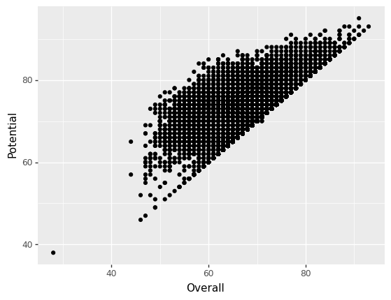

```python
ggplot(data= df) + geom_point(aes(x='Overall', y= 'Potential'))
```

```python
df.eval('Potential2 = Potential - Overall')
```

|  | ID | Name | Age | Photo | Nationality | Flag | Overall | Potential | Club | Club Logo | ... | GKDiving | GKHandling | GKKicking | GKPositioning | GKReflexes | Best Position | Best Overall Rating | Release Clause | DefensiveAwareness | Potential2 |
| --- | --- | --- | --- | --- | --- | --- | --- | --- | --- | --- | --- | --- | --- | --- | --- | --- | --- | --- | --- | --- | --- |
| 0 | 212198 | Bruno Fernandes | 26 | https://cdn.sofifa.com/players/212/198/22_60.png | Portugal | https://cdn.sofifa.com/flags/pt.png | 88 | 89 | Manchester United | https://cdn.sofifa.com/teams/11/30.png | ... | 12.0 | 14.0 | 15.0 | 8.0 | 14.0 | CAM | 88.0 | €206.9M | 72.0 | 1 |
| 1 | 209658 | L. Goretzka | 26 | https://cdn.sofifa.com/players/209/658/22_60.png | Germany | https://cdn.sofifa.com/flags/de.png | 87 | 88 | FC Bayern München | https://cdn.sofifa.com/teams/21/30.png | ... | 13.0 | 8.0 | 15.0 | 11.0 | 9.0 | CM | 87.0 | €160.4M | 74.0 | 1 |
| 2 | 176580 | L. Suárez | 34 | https://cdn.sofifa.com/players/176/580/22_60.png | Uruguay | https://cdn.sofifa.com/flags/uy.png | 88 | 88 | Atlético de Madrid | https://cdn.sofifa.com/teams/240/30.png | ... | 27.0 | 25.0 | 31.0 | 33.0 | 37.0 | ST | 88.0 | €91.2M | 42.0 | 0 |
| 3 | 192985 | K. De Bruyne | 30 | https://cdn.sofifa.com/players/192/985/22_60.png | Belgium | https://cdn.sofifa.com/flags/be.png | 91 | 91 | Manchester City | https://cdn.sofifa.com/teams/10/30.png | ... | 15.0 | 13.0 | 5.0 | 10.0 | 13.0 | CM | 91.0 | €232.2M | 68.0 | 0 |
| 4 | 224334 | M. Acuña | 29 | https://cdn.sofifa.com/players/224/334/22_60.png | Argentina | https://cdn.sofifa.com/flags/ar.png | 84 | 84 | Sevilla FC | https://cdn.sofifa.com/teams/481/30.png | ... | 8.0 | 14.0 | 13.0 | 13.0 | 14.0 | LB | 84.0 | €77.7M | 80.0 | 0 |
| ... | ... | ... | ... | ... | ... | ... | ... | ... | ... | ... | ... | ... | ... | ... | ... | ... | ... | ... | ... | ... | ... |
| 16705 | 240558 | 18 L. Clayton | 17 | https://cdn.sofifa.com/players/240/558/18_60.png | England | https://cdn.sofifa.com/flags/gb-eng.png | 53 | 70 | Cheltenham Town | https://cdn.sofifa.com/teams/1936/30.png | ... | 55.0 | 54.0 | 52.0 | 50.0 | 59.0 | GK | 52.0 | €238K | NaN | 17 |
| 16706 | 262846 | �. Dobre | 20 | https://cdn.sofifa.com/players/262/846/22_60.png | Romania | https://cdn.sofifa.com/flags/ro.png | 53 | 63 | FC Academica Clinceni | https://cdn.sofifa.com/teams/113391/30.png | ... | 57.0 | 52.0 | 53.0 | 48.0 | 58.0 | GK | 53.0 | €279K | 5.0 | 10 |
| 16707 | 241317 | 21 Xue Qinghao | 19 | https://cdn.sofifa.com/players/241/317/21_60.png | China PR | https://cdn.sofifa.com/flags/cn.png | 47 | 60 | Shanghai Shenhua FC | https://cdn.sofifa.com/teams/110955/30.png | ... | 49.0 | 48.0 | 45.0 | 38.0 | 52.0 | GK | 47.0 | €223K | 21.0 | 13 |
| 16708 | 259646 | A. Shaikh | 18 | https://cdn.sofifa.com/players/259/646/22_60.png | India | https://cdn.sofifa.com/flags/in.png | 47 | 67 | ATK Mohun Bagan FC | https://cdn.sofifa.com/teams/113146/30.png | ... | 49.0 | 41.0 | 39.0 | 45.0 | 49.0 | GK | 47.0 | €259K | 7.0 | 20 |
| 16709 | 178453 | 07 A. Censori | 17 | https://cdn.sofifa.com/players/178/453/07_60.png | Italy | https://cdn.sofifa.com/flags/it.png | 28 | 38 | Arezzo | https://cdn.sofifa.com/teams/110907/30.png | ... | 7.0 | 1.0 | 36.0 | 6.0 | 9.0 | ST | 36.0 | NaN | NaN | 10 |

16710 rows × 66 columns

#### 수정된 데이터프레임으로 다시 시각화를 하자

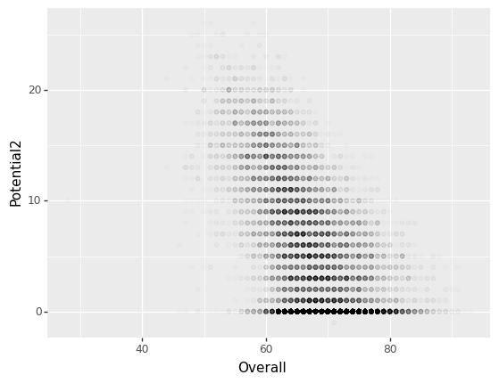

```python
ggplot(data = df.eval('Potential2 = Potential - Overall'))\
+ geom_point(aes(x='Overall',y= 'Potential2'),alpha =0.01)
```

#### 점들이 겹치는 부분이 있다. position = 'jitter'를 이용하여 점을 흩뿌리자

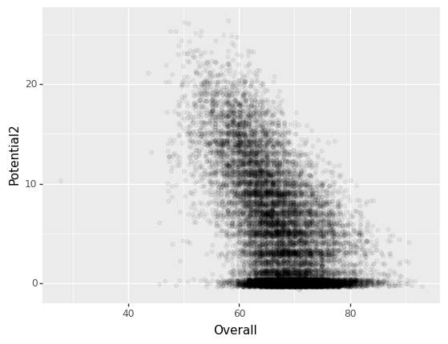

```python
ggplot(data= df.eval('Potential2 = Potential - Overall'))\
+ geom_point(aes(x='Overall',y='Potential2'),alpha = 0.05, position = 'jitter')
```

### 은퇴한 선수들을 제끼고 시각화

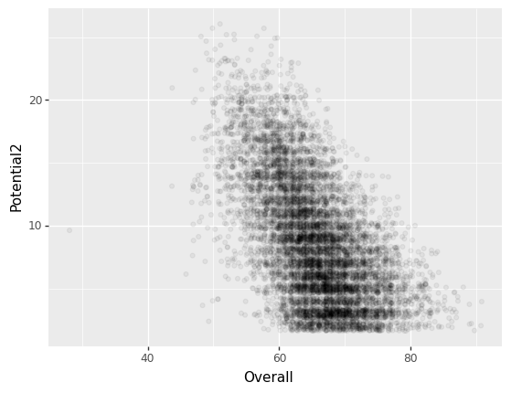

```python
ggplot(data= df.eval('Potential2 = Potential - Overall').query('Potential2 >1'))\
+ geom_point(aes(x='Overall',y='Potential2'),alpha = 0.05, position = 'jitter')
```

### 오버롤에 따라서 구간을 나누고 그 구간에 대응하는 boxplot을 그리자

```python
df.eval('Potential2 = Potential - Overall').query('Potential2 > 1')\
.Overall.describe()
```

```
count    9382.000000
mean       65.516308
std         6.408948
min        28.000000
25%        61.000000
50%        65.000000
75%        70.000000
max        91.000000
Name: Overall, dtype: float64
```

```python
def f(x):
    if x > 70:
        y='70<'
    elif x> 65:
        y= '65 ~ 70'
    elif x> 61:
        y= '61~ 65'
    else:
        y= '<61'
    return y
```

```python
df.eval('Potential2= Potential - Overall').query('Potential2 > 1 ')
```

|  | ID | Name | Age | Photo | Nationality | Flag | Overall | Potential | Club | Club Logo | ... | GKDiving | GKHandling | GKKicking | GKPositioning | GKReflexes | Best Position | Best Overall Rating | Release Clause | DefensiveAwareness | Potential2 |
| --- | --- | --- | --- | --- | --- | --- | --- | --- | --- | --- | --- | --- | --- | --- | --- | --- | --- | --- | --- | --- | --- |
| 11 | 226161 | Marcos Llorente | 26 | https://cdn.sofifa.com/players/226/161/22_60.png | Spain | https://cdn.sofifa.com/flags/es.png | 86 | 89 | Atlético de Madrid | https://cdn.sofifa.com/teams/240/30.png | ... | 13.0 | 6.0 | 6.0 | 11.0 | 15.0 | CAM | 87.0 | €187M | 79.0 | 3 |
| 14 | 225193 | Merino | 25 | https://cdn.sofifa.com/players/225/193/22_60.png | Spain | https://cdn.sofifa.com/flags/es.png | 83 | 87 | Real Sociedad | https://cdn.sofifa.com/teams/457/30.png | ... | 9.0 | 12.0 | 9.0 | 13.0 | 14.0 | CM | 85.0 | €108.8M | 80.0 | 4 |
| 15 | 224232 | N. Barella | 24 | https://cdn.sofifa.com/players/224/232/22_60.png | Italy | https://cdn.sofifa.com/flags/it.png | 84 | 89 | Inter | https://cdn.sofifa.com/teams/44/30.png | ... | 11.0 | 5.0 | 13.0 | 14.0 | 11.0 | CM | 87.0 | €112.7M | 74.0 | 5 |
| 17 | 228702 | F. de Jong | 24 | https://cdn.sofifa.com/players/228/702/22_60.png | Netherlands | https://cdn.sofifa.com/flags/nl.png | 87 | 92 | FC Barcelona | https://cdn.sofifa.com/teams/241/30.png | ... | 7.0 | 13.0 | 10.0 | 10.0 | 9.0 | CM | 89.0 | €253.9M | 76.0 | 5 |
| 24 | 231281 | T. Alexander-Arnold | 22 | https://cdn.sofifa.com/players/231/281/22_60.png | England | https://cdn.sofifa.com/flags/gb-eng.png | 87 | 92 | Liverpool | https://cdn.sofifa.com/teams/9/30.png | ... | 14.0 | 15.0 | 14.0 | 6.0 | 7.0 | RB | 87.0 | €219.5M | 80.0 | 5 |
| ... | ... | ... | ... | ... | ... | ... | ... | ... | ... | ... | ... | ... | ... | ... | ... | ... | ... | ... | ... | ... | ... |
| 16705 | 240558 | 18 L. Clayton | 17 | https://cdn.sofifa.com/players/240/558/18_60.png | England | https://cdn.sofifa.com/flags/gb-eng.png | 53 | 70 | Cheltenham Town | https://cdn.sofifa.com/teams/1936/30.png | ... | 55.0 | 54.0 | 52.0 | 50.0 | 59.0 | GK | 52.0 | €238K | NaN | 17 |
| 16706 | 262846 | �. Dobre | 20 | https://cdn.sofifa.com/players/262/846/22_60.png | Romania | https://cdn.sofifa.com/flags/ro.png | 53 | 63 | FC Academica Clinceni | https://cdn.sofifa.com/teams/113391/30.png | ... | 57.0 | 52.0 | 53.0 | 48.0 | 58.0 | GK | 53.0 | €279K | 5.0 | 10 |
| 16707 | 241317 | 21 Xue Qinghao | 19 | https://cdn.sofifa.com/players/241/317/21_60.png | China PR | https://cdn.sofifa.com/flags/cn.png | 47 | 60 | Shanghai Shenhua FC | https://cdn.sofifa.com/teams/110955/30.png | ... | 49.0 | 48.0 | 45.0 | 38.0 | 52.0 | GK | 47.0 | €223K | 21.0 | 13 |
| 16708 | 259646 | A. Shaikh | 18 | https://cdn.sofifa.com/players/259/646/22_60.png | India | https://cdn.sofifa.com/flags/in.png | 47 | 67 | ATK Mohun Bagan FC | https://cdn.sofifa.com/teams/113146/30.png | ... | 49.0 | 41.0 | 39.0 | 45.0 | 49.0 | GK | 47.0 | €259K | 7.0 | 20 |
| 16709 | 178453 | 07 A. Censori | 17 | https://cdn.sofifa.com/players/178/453/07_60.png | Italy | https://cdn.sofifa.com/flags/it.png | 28 | 38 | Arezzo | https://cdn.sofifa.com/teams/110907/30.png | ... | 7.0 | 1.0 | 36.0 | 6.0 | 9.0 | ST | 36.0 | NaN | NaN | 10 |

9382 rows × 66 columns

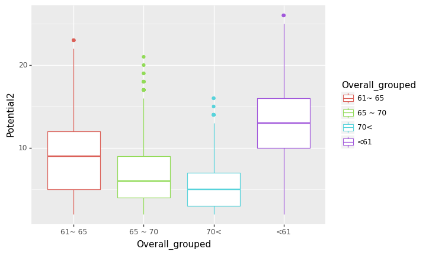

```python
ggplot(data=df.eval('Potential2 = Potential - Overall').query('Potential2 > 1')\
.assign(Overall_grouped= lambda df: list(map(f,df.Overall))))\
    + geom_boxplot(aes(x='Overall_grouped',y='Potential2',color='Overall_grouped'))
```

```python
df.eval('Potential2 = Potential - Overall').query('Potential2 > 1')\
.assign(Overall_grouped= lambda df: list(map(f,df.Overall)))\
.query("Overall_grouped == '<61'").Overall.mean()
```

```
57.69464063149148
```

### 방법1

```python
def _f(x):
    if x == '70<':
        y= 74.62903225806451
    elif x== '65 ~ 70' :
        y= 67.84544758990053
    elif x == '61~ 65':
        y= 63.5580155801558
    else:
        y= 57.69464063149148
    return y
```

```python
df.eval('Potential2 = Potential - Overall').query('Potential2 > 1')\
.assign(Overall_grouped= lambda df: list(map(f,df.Overall)))\
.assign(Overall_x= lambda df: list(map(_f, df.Overall_grouped)))
```

|  | ID | Name | Age | Photo | Nationality | Flag | Overall | Potential | Club | Club Logo | ... | GKKicking | GKPositioning | GKReflexes | Best Position | Best Overall Rating | Release Clause | DefensiveAwareness | Potential2 | Overall_grouped | Overall_x |
| --- | --- | --- | --- | --- | --- | --- | --- | --- | --- | --- | --- | --- | --- | --- | --- | --- | --- | --- | --- | --- | --- |
| 11 | 226161 | Marcos Llorente | 26 | https://cdn.sofifa.com/players/226/161/22_60.png | Spain | https://cdn.sofifa.com/flags/es.png | 86 | 89 | Atlético de Madrid | https://cdn.sofifa.com/teams/240/30.png | ... | 6.0 | 11.0 | 15.0 | CAM | 87.0 | €187M | 79.0 | 3 | 70< | 74.629032 |
| 14 | 225193 | Merino | 25 | https://cdn.sofifa.com/players/225/193/22_60.png | Spain | https://cdn.sofifa.com/flags/es.png | 83 | 87 | Real Sociedad | https://cdn.sofifa.com/teams/457/30.png | ... | 9.0 | 13.0 | 14.0 | CM | 85.0 | €108.8M | 80.0 | 4 | 70< | 74.629032 |
| 15 | 224232 | N. Barella | 24 | https://cdn.sofifa.com/players/224/232/22_60.png | Italy | https://cdn.sofifa.com/flags/it.png | 84 | 89 | Inter | https://cdn.sofifa.com/teams/44/30.png | ... | 13.0 | 14.0 | 11.0 | CM | 87.0 | €112.7M | 74.0 | 5 | 70< | 74.629032 |
| 17 | 228702 | F. de Jong | 24 | https://cdn.sofifa.com/players/228/702/22_60.png | Netherlands | https://cdn.sofifa.com/flags/nl.png | 87 | 92 | FC Barcelona | https://cdn.sofifa.com/teams/241/30.png | ... | 10.0 | 10.0 | 9.0 | CM | 89.0 | €253.9M | 76.0 | 5 | 70< | 74.629032 |
| 24 | 231281 | T. Alexander-Arnold | 22 | https://cdn.sofifa.com/players/231/281/22_60.png | England | https://cdn.sofifa.com/flags/gb-eng.png | 87 | 92 | Liverpool | https://cdn.sofifa.com/teams/9/30.png | ... | 14.0 | 6.0 | 7.0 | RB | 87.0 | €219.5M | 80.0 | 5 | 70< | 74.629032 |
| ... | ... | ... | ... | ... | ... | ... | ... | ... | ... | ... | ... | ... | ... | ... | ... | ... | ... | ... | ... | ... | ... |
| 16705 | 240558 | 18 L. Clayton | 17 | https://cdn.sofifa.com/players/240/558/18_60.png | England | https://cdn.sofifa.com/flags/gb-eng.png | 53 | 70 | Cheltenham Town | https://cdn.sofifa.com/teams/1936/30.png | ... | 52.0 | 50.0 | 59.0 | GK | 52.0 | €238K | NaN | 17 | <61 | 57.694641 |
| 16706 | 262846 | �. Dobre | 20 | https://cdn.sofifa.com/players/262/846/22_60.png | Romania | https://cdn.sofifa.com/flags/ro.png | 53 | 63 | FC Academica Clinceni | https://cdn.sofifa.com/teams/113391/30.png | ... | 53.0 | 48.0 | 58.0 | GK | 53.0 | €279K | 5.0 | 10 | <61 | 57.694641 |
| 16707 | 241317 | 21 Xue Qinghao | 19 | https://cdn.sofifa.com/players/241/317/21_60.png | China PR | https://cdn.sofifa.com/flags/cn.png | 47 | 60 | Shanghai Shenhua FC | https://cdn.sofifa.com/teams/110955/30.png | ... | 45.0 | 38.0 | 52.0 | GK | 47.0 | €223K | 21.0 | 13 | <61 | 57.694641 |
| 16708 | 259646 | A. Shaikh | 18 | https://cdn.sofifa.com/players/259/646/22_60.png | India | https://cdn.sofifa.com/flags/in.png | 47 | 67 | ATK Mohun Bagan FC | https://cdn.sofifa.com/teams/113146/30.png | ... | 39.0 | 45.0 | 49.0 | GK | 47.0 | €259K | 7.0 | 20 | <61 | 57.694641 |
| 16709 | 178453 | 07 A. Censori | 17 | https://cdn.sofifa.com/players/178/453/07_60.png | Italy | https://cdn.sofifa.com/flags/it.png | 28 | 38 | Arezzo | https://cdn.sofifa.com/teams/110907/30.png | ... | 36.0 | 6.0 | 9.0 | ST | 36.0 | NaN | NaN | 10 | <61 | 57.694641 |

9382 rows × 68 columns

```python
df2= df.eval('Potential2 = Potential - Overall').query('Potential2 > 1')\
.assign(Overall_grouped= lambda df: list(map(f,df.Overall)))\
.assign(Overall_x= lambda df: list(map(_f,df.Overall_grouped)))
df2
```

|  | ID | Name | Age | Photo | Nationality | Flag | Overall | Potential | Club | Club Logo | ... | GKKicking | GKPositioning | GKReflexes | Best Position | Best Overall Rating | Release Clause | DefensiveAwareness | Potential2 | Overall_grouped | Overall_x |
| --- | --- | --- | --- | --- | --- | --- | --- | --- | --- | --- | --- | --- | --- | --- | --- | --- | --- | --- | --- | --- | --- |
| 11 | 226161 | Marcos Llorente | 26 | https://cdn.sofifa.com/players/226/161/22_60.png | Spain | https://cdn.sofifa.com/flags/es.png | 86 | 89 | Atlético de Madrid | https://cdn.sofifa.com/teams/240/30.png | ... | 6.0 | 11.0 | 15.0 | CAM | 87.0 | €187M | 79.0 | 3 | 70< | 74.629032 |
| 14 | 225193 | Merino | 25 | https://cdn.sofifa.com/players/225/193/22_60.png | Spain | https://cdn.sofifa.com/flags/es.png | 83 | 87 | Real Sociedad | https://cdn.sofifa.com/teams/457/30.png | ... | 9.0 | 13.0 | 14.0 | CM | 85.0 | €108.8M | 80.0 | 4 | 70< | 74.629032 |
| 15 | 224232 | N. Barella | 24 | https://cdn.sofifa.com/players/224/232/22_60.png | Italy | https://cdn.sofifa.com/flags/it.png | 84 | 89 | Inter | https://cdn.sofifa.com/teams/44/30.png | ... | 13.0 | 14.0 | 11.0 | CM | 87.0 | €112.7M | 74.0 | 5 | 70< | 74.629032 |
| 17 | 228702 | F. de Jong | 24 | https://cdn.sofifa.com/players/228/702/22_60.png | Netherlands | https://cdn.sofifa.com/flags/nl.png | 87 | 92 | FC Barcelona | https://cdn.sofifa.com/teams/241/30.png | ... | 10.0 | 10.0 | 9.0 | CM | 89.0 | €253.9M | 76.0 | 5 | 70< | 74.629032 |
| 24 | 231281 | T. Alexander-Arnold | 22 | https://cdn.sofifa.com/players/231/281/22_60.png | England | https://cdn.sofifa.com/flags/gb-eng.png | 87 | 92 | Liverpool | https://cdn.sofifa.com/teams/9/30.png | ... | 14.0 | 6.0 | 7.0 | RB | 87.0 | €219.5M | 80.0 | 5 | 70< | 74.629032 |
| ... | ... | ... | ... | ... | ... | ... | ... | ... | ... | ... | ... | ... | ... | ... | ... | ... | ... | ... | ... | ... | ... |
| 16705 | 240558 | 18 L. Clayton | 17 | https://cdn.sofifa.com/players/240/558/18_60.png | England | https://cdn.sofifa.com/flags/gb-eng.png | 53 | 70 | Cheltenham Town | https://cdn.sofifa.com/teams/1936/30.png | ... | 52.0 | 50.0 | 59.0 | GK | 52.0 | €238K | NaN | 17 | <61 | 57.694641 |
| 16706 | 262846 | �. Dobre | 20 | https://cdn.sofifa.com/players/262/846/22_60.png | Romania | https://cdn.sofifa.com/flags/ro.png | 53 | 63 | FC Academica Clinceni | https://cdn.sofifa.com/teams/113391/30.png | ... | 53.0 | 48.0 | 58.0 | GK | 53.0 | €279K | 5.0 | 10 | <61 | 57.694641 |
| 16707 | 241317 | 21 Xue Qinghao | 19 | https://cdn.sofifa.com/players/241/317/21_60.png | China PR | https://cdn.sofifa.com/flags/cn.png | 47 | 60 | Shanghai Shenhua FC | https://cdn.sofifa.com/teams/110955/30.png | ... | 45.0 | 38.0 | 52.0 | GK | 47.0 | €223K | 21.0 | 13 | <61 | 57.694641 |
| 16708 | 259646 | A. Shaikh | 18 | https://cdn.sofifa.com/players/259/646/22_60.png | India | https://cdn.sofifa.com/flags/in.png | 47 | 67 | ATK Mohun Bagan FC | https://cdn.sofifa.com/teams/113146/30.png | ... | 39.0 | 45.0 | 49.0 | GK | 47.0 | €259K | 7.0 | 20 | <61 | 57.694641 |
| 16709 | 178453 | 07 A. Censori | 17 | https://cdn.sofifa.com/players/178/453/07_60.png | Italy | https://cdn.sofifa.com/flags/it.png | 28 | 38 | Arezzo | https://cdn.sofifa.com/teams/110907/30.png | ... | 36.0 | 6.0 | 9.0 | ST | 36.0 | NaN | NaN | 10 | <61 | 57.694641 |

9382 rows × 68 columns

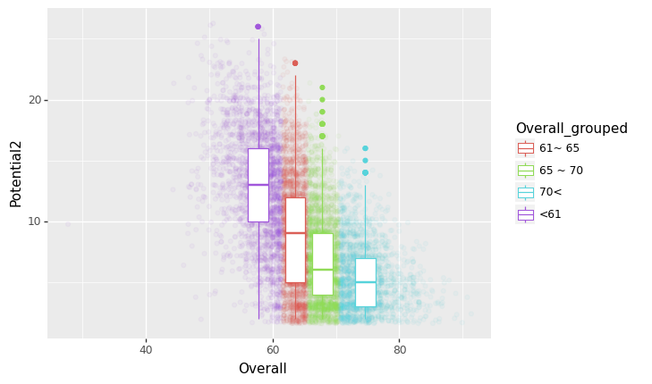

```python
ggplot(data=df2)\
+geom_point(aes(x='Overall',y='Potential2',color='Overall_grouped'),position='jitter',alpha=0.05)\
+geom_boxplot(aes(x='Overall_x',y='Potential2',color='Overall_grouped'))
```

### 방법2

```python
_df = df.eval('Potential2 = Potential - Overall').query('Potential2 > 1')\
.assign(Overall_grouped= lambda df: list(map(f,df.Overall)))
```

```python
_df
```

|  | ID | Name | Age | Photo | Nationality | Flag | Overall | Potential | Club | Club Logo | ... | GKHandling | GKKicking | GKPositioning | GKReflexes | Best Position | Best Overall Rating | Release Clause | DefensiveAwareness | Potential2 | Overall_grouped |
| --- | --- | --- | --- | --- | --- | --- | --- | --- | --- | --- | --- | --- | --- | --- | --- | --- | --- | --- | --- | --- | --- |
| 11 | 226161 | Marcos Llorente | 26 | https://cdn.sofifa.com/players/226/161/22_60.png | Spain | https://cdn.sofifa.com/flags/es.png | 86 | 89 | Atlético de Madrid | https://cdn.sofifa.com/teams/240/30.png | ... | 6.0 | 6.0 | 11.0 | 15.0 | CAM | 87.0 | €187M | 79.0 | 3 | 70< |
| 14 | 225193 | Merino | 25 | https://cdn.sofifa.com/players/225/193/22_60.png | Spain | https://cdn.sofifa.com/flags/es.png | 83 | 87 | Real Sociedad | https://cdn.sofifa.com/teams/457/30.png | ... | 12.0 | 9.0 | 13.0 | 14.0 | CM | 85.0 | €108.8M | 80.0 | 4 | 70< |
| 15 | 224232 | N. Barella | 24 | https://cdn.sofifa.com/players/224/232/22_60.png | Italy | https://cdn.sofifa.com/flags/it.png | 84 | 89 | Inter | https://cdn.sofifa.com/teams/44/30.png | ... | 5.0 | 13.0 | 14.0 | 11.0 | CM | 87.0 | €112.7M | 74.0 | 5 | 70< |
| 17 | 228702 | F. de Jong | 24 | https://cdn.sofifa.com/players/228/702/22_60.png | Netherlands | https://cdn.sofifa.com/flags/nl.png | 87 | 92 | FC Barcelona | https://cdn.sofifa.com/teams/241/30.png | ... | 13.0 | 10.0 | 10.0 | 9.0 | CM | 89.0 | €253.9M | 76.0 | 5 | 70< |
| 24 | 231281 | T. Alexander-Arnold | 22 | https://cdn.sofifa.com/players/231/281/22_60.png | England | https://cdn.sofifa.com/flags/gb-eng.png | 87 | 92 | Liverpool | https://cdn.sofifa.com/teams/9/30.png | ... | 15.0 | 14.0 | 6.0 | 7.0 | RB | 87.0 | €219.5M | 80.0 | 5 | 70< |
| ... | ... | ... | ... | ... | ... | ... | ... | ... | ... | ... | ... | ... | ... | ... | ... | ... | ... | ... | ... | ... | ... |
| 16705 | 240558 | 18 L. Clayton | 17 | https://cdn.sofifa.com/players/240/558/18_60.png | England | https://cdn.sofifa.com/flags/gb-eng.png | 53 | 70 | Cheltenham Town | https://cdn.sofifa.com/teams/1936/30.png | ... | 54.0 | 52.0 | 50.0 | 59.0 | GK | 52.0 | €238K | NaN | 17 | <61 |
| 16706 | 262846 | �. Dobre | 20 | https://cdn.sofifa.com/players/262/846/22_60.png | Romania | https://cdn.sofifa.com/flags/ro.png | 53 | 63 | FC Academica Clinceni | https://cdn.sofifa.com/teams/113391/30.png | ... | 52.0 | 53.0 | 48.0 | 58.0 | GK | 53.0 | €279K | 5.0 | 10 | <61 |
| 16707 | 241317 | 21 Xue Qinghao | 19 | https://cdn.sofifa.com/players/241/317/21_60.png | China PR | https://cdn.sofifa.com/flags/cn.png | 47 | 60 | Shanghai Shenhua FC | https://cdn.sofifa.com/teams/110955/30.png | ... | 48.0 | 45.0 | 38.0 | 52.0 | GK | 47.0 | €223K | 21.0 | 13 | <61 |
| 16708 | 259646 | A. Shaikh | 18 | https://cdn.sofifa.com/players/259/646/22_60.png | India | https://cdn.sofifa.com/flags/in.png | 47 | 67 | ATK Mohun Bagan FC | https://cdn.sofifa.com/teams/113146/30.png | ... | 41.0 | 39.0 | 45.0 | 49.0 | GK | 47.0 | €259K | 7.0 | 20 | <61 |
| 16709 | 178453 | 07 A. Censori | 17 | https://cdn.sofifa.com/players/178/453/07_60.png | Italy | https://cdn.sofifa.com/flags/it.png | 28 | 38 | Arezzo | https://cdn.sofifa.com/teams/110907/30.png | ... | 1.0 | 36.0 | 6.0 | 9.0 | ST | 36.0 | NaN | NaN | 10 | <61 |

9382 rows × 67 columns

```python
df3 = _df.groupby(by='Overall_grouped').agg({'Overall':np.mean}).reset_index()\
.rename(columns={'Overall':'Overall_x'}).merge(_df)
```

```python
df3
```

|  | Overall_grouped | Overall_x | ID | Name | Age | Photo | Nationality | Flag | Overall | Potential | ... | GKDiving | GKHandling | GKKicking | GKPositioning | GKReflexes | Best Position | Best Overall Rating | Release Clause | DefensiveAwareness | Potential2 |
| --- | --- | --- | --- | --- | --- | --- | --- | --- | --- | --- | --- | --- | --- | --- | --- | --- | --- | --- | --- | --- | --- |
| 0 | 61~ 65 | 63.558016 | 222405 | L. Kinsella | 25 | https://cdn.sofifa.com/players/222/405/22_60.png | Republic of Ireland | https://cdn.sofifa.com/flags/ie.png | 64 | 67 | ... | 16.0 | 11.0 | 15.0 | 8.0 | 10.0 | CDM | 69.0 | €1.4M | 64.0 | 3 |
| 1 | 61~ 65 | 63.558016 | 260282 | T. Akimoto | 23 | https://cdn.sofifa.com/players/260/282/22_60.png | Japan | https://cdn.sofifa.com/flags/jp.png | 65 | 71 | ... | 7.0 | 14.0 | 9.0 | 6.0 | 6.0 | ST | 67.0 | €1.7M | 59.0 | 6 |
| 2 | 61~ 65 | 63.558016 | 210742 | M. Hallberg | 25 | https://cdn.sofifa.com/players/210/742/22_60.png | Sweden | https://cdn.sofifa.com/flags/se.png | 65 | 67 | ... | 15.0 | 8.0 | 8.0 | 8.0 | 6.0 | CAM | 67.0 | €1.6M | 61.0 | 2 |
| 3 | 61~ 65 | 63.558016 | 215820 | L. Donnelly | 25 | https://cdn.sofifa.com/players/215/820/22_60.png | Northern Ireland | https://cdn.sofifa.com/flags/gb-nir.png | 65 | 68 | ... | 15.0 | 15.0 | 14.0 | 15.0 | 16.0 | CB | 67.0 | €1.6M | 64.0 | 3 |
| 4 | 61~ 65 | 63.558016 | 243963 | K. Magennis | 22 | https://cdn.sofifa.com/players/243/963/22_60.png | Scotland | https://cdn.sofifa.com/flags/gb-sct.png | 65 | 71 | ... | 6.0 | 10.0 | 10.0 | 15.0 | 10.0 | RM | 68.0 | €2.1M | 57.0 | 6 |
| ... | ... | ... | ... | ... | ... | ... | ... | ... | ... | ... | ... | ... | ... | ... | ... | ... | ... | ... | ... | ... | ... |
| 9377 | <61 | 57.694641 | 240558 | 18 L. Clayton | 17 | https://cdn.sofifa.com/players/240/558/18_60.png | England | https://cdn.sofifa.com/flags/gb-eng.png | 53 | 70 | ... | 55.0 | 54.0 | 52.0 | 50.0 | 59.0 | GK | 52.0 | €238K | NaN | 17 |
| 9378 | <61 | 57.694641 | 262846 | �. Dobre | 20 | https://cdn.sofifa.com/players/262/846/22_60.png | Romania | https://cdn.sofifa.com/flags/ro.png | 53 | 63 | ... | 57.0 | 52.0 | 53.0 | 48.0 | 58.0 | GK | 53.0 | €279K | 5.0 | 10 |
| 9379 | <61 | 57.694641 | 241317 | 21 Xue Qinghao | 19 | https://cdn.sofifa.com/players/241/317/21_60.png | China PR | https://cdn.sofifa.com/flags/cn.png | 47 | 60 | ... | 49.0 | 48.0 | 45.0 | 38.0 | 52.0 | GK | 47.0 | €223K | 21.0 | 13 |
| 9380 | <61 | 57.694641 | 259646 | A. Shaikh | 18 | https://cdn.sofifa.com/players/259/646/22_60.png | India | https://cdn.sofifa.com/flags/in.png | 47 | 67 | ... | 49.0 | 41.0 | 39.0 | 45.0 | 49.0 | GK | 47.0 | €259K | 7.0 | 20 |
| 9381 | <61 | 57.694641 | 178453 | 07 A. Censori | 17 | https://cdn.sofifa.com/players/178/453/07_60.png | Italy | https://cdn.sofifa.com/flags/it.png | 28 | 38 | ... | 7.0 | 1.0 | 36.0 | 6.0 | 9.0 | ST | 36.0 | NaN | NaN | 10 |

9382 rows × 68 columns

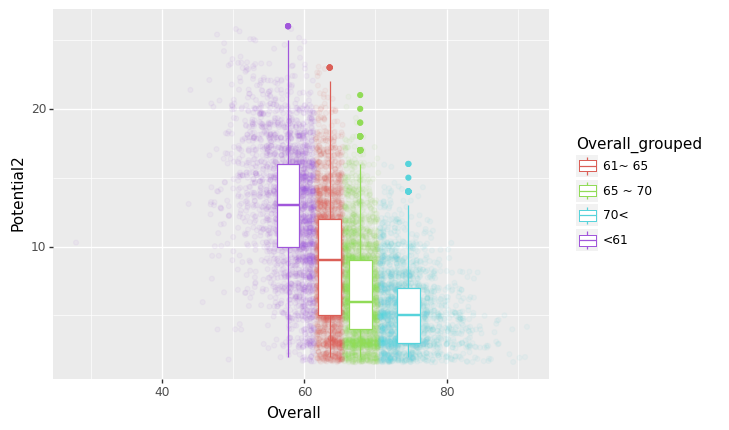

```python
ggplot(data=df3)\
+geom_point(aes(x='Overall',y='Potential2',color='Overall_grouped'),position='jitter',alpha=0.05)\
+geom_boxplot(aes(x='Overall_x',y='Potential2',color='Overall_grouped'))
```

## Groupby

```python
df=pd.read_csv('https://raw.githubusercontent.com/PacktPublishing/Pandas-Cookbook/master/data/flights.csv')
df.info()
```

```
<class 'pandas.core.frame.DataFrame'>
RangeIndex: 58492 entries, 0 to 58491
Data columns (total 14 columns):
 #   Column     Non-Null Count  Dtype
---  ------     --------------  -----
 0   MONTH      58492 non-null  int64
 1   DAY        58492 non-null  int64
 2   WEEKDAY    58492 non-null  int64
 3   AIRLINE    58492 non-null  object
 4   ORG_AIR    58492 non-null  object
 5   DEST_AIR   58492 non-null  object
 6   SCHED_DEP  58492 non-null  int64
 7   DEP_DELAY  57659 non-null  float64
 8   AIR_TIME   57474 non-null  float64
 9   DIST       58492 non-null  int64
 10  SCHED_ARR  58492 non-null  int64
 11  ARR_DELAY  57474 non-null  float64
 12  DIVERTED   58492 non-null  int64
 13  CANCELLED  58492 non-null  int64
dtypes: float64(3), int64(8), object(3)
memory usage: 6.2+ MB
```

### group_by

`-` 데이터프레임을 여러개의 서브 데이터프레임으로 나누는 기능  
`-` 단독으로 쓸 이유는 별로 없다. -> 그룹을 나누고 각각의 그룹마다 어떠한 '변수'에 '연산'을 하기 위함

```python
df.groupby(by="AIRLINE")
```

```
<pandas.core.groupby.generic.DataFrameGroupBy object at 0x000001C2119601C0>
```

`-` 지금이 항공사별로 데이터프레임이 나누어진 상태

```python
grouped = df.groupby(by="AIRLINE")
grouped.groups.keys()
```

```
dict_keys(['AA', 'AS', 'B6', 'DL', 'EV', 'F9', 'HA', 'MQ', 'NK', 'OO', 'UA', 'US', 'VX', 'WN'])
```

```python
display(grouped.get_group('AS'))
```

|  | MONTH | DAY | WEEKDAY | AIRLINE | ORG_AIR | DEST_AIR | SCHED_DEP | DEP_DELAY | AIR_TIME | DIST | SCHED_ARR | ARR_DELAY | DIVERTED | CANCELLED |
| --- | --- | --- | --- | --- | --- | --- | --- | --- | --- | --- | --- | --- | --- | --- |
| 38 | 1 | 1 | 4 | AS | PHX | SEA | 1505 | -2.0 | 155.0 | 1107 | 1702 | -3.0 | 0 | 0 |
| 198 | 1 | 2 | 5 | AS | LAX | SEA | 2110 | 5.0 | 145.0 | 954 | 2352 | 8.0 | 0 | 0 |
| 241 | 1 | 2 | 5 | AS | LAS | PDX | 650 | -5.0 | 117.0 | 763 | 906 | -3.0 | 0 | 0 |
| 277 | 1 | 2 | 5 | AS | ORD | ANC | 935 | -1.0 | 402.0 | 2846 | 1339 | -6.0 | 0 | 0 |
| 397 | 1 | 3 | 6 | AS | LAS | SEA | 1300 | 48.0 | 137.0 | 867 | 1535 | 47.0 | 0 | 0 |
| ... | ... | ... | ... | ... | ... | ... | ... | ... | ... | ... | ... | ... | ... | ... |
| 58305 | 12 | 30 | 3 | AS | LAX | SEA | 1325 | -2.0 | 134.0 | 954 | 1608 | -7.0 | 0 | 0 |
| 58355 | 12 | 31 | 4 | AS | PHX | SEA | 1200 | -5.0 | 145.0 | 1107 | 1407 | -24.0 | 0 | 0 |
| 58404 | 12 | 31 | 4 | AS | SFO | SLC | 2110 | -2.0 | 80.0 | 599 | 2358 | -4.0 | 0 | 0 |
| 58407 | 12 | 31 | 4 | AS | SFO | PDX | 645 | -2.0 | 81.0 | 550 | 832 | -3.0 | 0 | 0 |
| 58428 | 12 | 31 | 4 | AS | LAX | SEA | 1420 | -8.0 | 127.0 | 954 | 1709 | -25.0 | 0 | 0 |

768 rows × 14 columns

## [airline] -> {ARR_DELAY:mean}

### 방법 1: groupby() -> .agg({colname: function})

#### 예시1

```python
df.groupby(by="AIRLINE").agg({'ARR_DELAY':np.mean})
```

| AIRLINE | ARR_DELAY |
| --- | --- |
| AA | 5.542661 |
| AS | -0.833333 |
| B6 | 8.692593 |
| DL | 0.339691 |
| EV | 7.034580 |
| F9 | 13.630651 |
| HA | 4.972973 |
| MQ | 6.860591 |
| NK | 18.436070 |
| OO | 7.593463 |
| UA | 7.765755 |
| US | 1.681105 |
| VX | 5.348884 |
| WN | 6.397353 |

#### 예시2

```python
df.groupby(by= "AIRLINE").agg({'ARR_DELAY':'mean'})
```

| AIRLINE | ARR_DELAY |
| --- | --- |
| AA | 5.542661 |
| AS | -0.833333 |
| B6 | 8.692593 |
| DL | 0.339691 |
| EV | 7.034580 |
| F9 | 13.630651 |
| HA | 4.972973 |
| MQ | 6.860591 |
| NK | 18.436070 |
| OO | 7.593463 |
| UA | 7.765755 |
| US | 1.681105 |
| VX | 5.348884 |
| WN | 6.397353 |

### 방법2: groupby() -> key로 column 선택 -> .agg(f) or .f()

#### 예시1

```python
df.groupby(by='AIRLINE')['ARR_DELAY'].agg(np.mean)
```

```
AIRLINE
AA     5.542661
AS    -0.833333
B6     8.692593
DL     0.339691
EV     7.034580
F9    13.630651
HA     4.972973
MQ     6.860591
NK    18.436070
OO     7.593463
UA     7.765755
US     1.681105
VX     5.348884
WN     6.397353
Name: ARR_DELAY, dtype: float64
```

#### 예시2

```python
df.groupby(by = 'AIRLINE')['ARR_DELAY'].agg("mean")
```

```
AIRLINE
AA     5.542661
AS    -0.833333
B6     8.692593
DL     0.339691
EV     7.034580
F9    13.630651
HA     4.972973
MQ     6.860591
NK    18.436070
OO     7.593463
UA     7.765755
US     1.681105
VX     5.348884
WN     6.397353
Name: ARR_DELAY, dtype: float64
```

#### 예시3

```python
df.groupby(by='AIRLINE')['ARR_DELAY'].mean()
```

```
AIRLINE
AA     5.542661
AS    -0.833333
B6     8.692593
DL     0.339691
EV     7.034580
F9    13.630651
HA     4.972973
MQ     6.860591
NK    18.436070
OO     7.593463
UA     7.765755
US     1.681105
VX     5.348884
WN     6.397353
Name: ARR_DELAY, dtype: float64
```

## EX2: [AIRLINE,WEEKDAY] $\to$ {CANCELLED:sum}

### 방법1

#### 예시1

```python
df.groupby(by=["AIRLINE","WEEKDAY"]).agg({"CANCELLED":np.sum})
```

| AIRLINE | WEEKDAY | CANCELLED |
| --- | --- | --- |
| AA | 1 | 41 |
|  | 2 | 9 |
|  | 3 | 16 |
|  | 4 | 20 |
|  | 5 | 18 |
| ... | ... | ... |
| WN | 3 | 18 |
|  | 4 | 10 |
|  | 5 | 7 |
|  | 6 | 10 |
|  | 7 | 7 |

98 rows × 1 columns

#### 예시2

```python
df.groupby(by=["AIRLINE","WEEKDAY"]).agg({"CANCELLED":"sum"})
```

| AIRLINE | WEEKDAY | CANCELLED |
| --- | --- | --- |
| AA | 1 | 41 |
|  | 2 | 9 |
|  | 3 | 16 |
|  | 4 | 20 |
|  | 5 | 18 |
| ... | ... | ... |
| WN | 3 | 18 |
|  | 4 | 10 |
|  | 5 | 7 |
|  | 6 | 10 |
|  | 7 | 7 |

98 rows × 1 columns

### 방법2

#### 예시1

```python
df.groupby(by=["AIRLINE","WEEKDAY"])[["CANCELLED"]].agg(np.sum)
```

| AIRLINE | WEEKDAY | CANCELLED |
| --- | --- | --- |
| AA | 1 | 41 |
|  | 2 | 9 |
|  | 3 | 16 |
|  | 4 | 20 |
|  | 5 | 18 |
| ... | ... | ... |
| WN | 3 | 18 |
|  | 4 | 10 |
|  | 5 | 7 |
|  | 6 | 10 |
|  | 7 | 7 |

98 rows × 1 columns

#### 예시2

```python
df.groupby(by=["AIRLINE","WEEKDAY"])["CANCELLED"].agg("sum")
```

```
AIRLINE  WEEKDAY
AA       1          41
         2           9
         3          16
         4          20
         5          18
                    ..
WN       3          18
         4          10
         5           7
         6          10
         7           7
Name: CANCELLED, Length: 98, dtype: int64
```

#### 예시3

```python
df.groupby(by=["AIRLINE","WEEKDAY"])["CANCELLED"].sum()
```

```
AIRLINE  WEEKDAY
AA       1          41
         2           9
         3          16
         4          20
         5          18
                    ..
WN       3          18
         4          10
         5           7
         6          10
         7           7
Name: CANCELLED, Length: 98, dtype: int64
```

```python
df.DIVERTED
```

```
0        0
1        0
2        0
3        0
4        0
        ..
58487    0
58488    0
58489    0
58490    0
58491    0
Name: DIVERTED, Length: 58492, dtype: int64
```

## EX3: [AIRLINE,WEEKDAY] $\to$ {CANCELLED:sum,mean}, {DIVERTED: sum,mean}

### 방법 1

#### 예시1

```python
df.groupby(["AIRLINE","WEEKDAY"])\
.agg({"CANCELLED":[np.sum,np.mean],"DIVERTED":[np.sum,np.mean]})
```

| AIRLINE | WEEKDAY | CANCELLED sum | CANCELLED mean | DIVERTED sum | DIVERTED mean |
| --- | --- | --- | --- | --- | --- |
| AA | 1 | 41 | 0.032106 | 6 | 0.004699 |
|  | 2 | 9 | 0.007341 | 2 | 0.001631 |
|  | 3 | 16 | 0.011949 | 2 | 0.001494 |
|  | 4 | 20 | 0.015004 | 5 | 0.003751 |
|  | 5 | 18 | 0.014151 | 1 | 0.000786 |
| ... | ... | ... | ... | ... | ... |
| WN | 3 | 18 | 0.014118 | 2 | 0.001569 |
|  | 4 | 10 | 0.007911 | 4 | 0.003165 |
|  | 5 | 7 | 0.005828 | 0 | 0.000000 |
|  | 6 | 10 | 0.010132 | 3 | 0.003040 |
|  | 7 | 7 | 0.006066 | 3 | 0.002600 |

98 rows × 4 columns

#### 예시2

```python
df.groupby(["AIRLINE","WEEKDAY"])\
.agg({"CANCELLED":["sum","mean"],"DIVERTED":["sum","mean"]})
```

| AIRLINE | WEEKDAY | CANCELLED sum | CANCELLED mean | DIVERTED sum | DIVERTED mean |
| --- | --- | --- | --- | --- | --- |
| AA | 1 | 41 | 0.032106 | 6 | 0.004699 |
|  | 2 | 9 | 0.007341 | 2 | 0.001631 |
|  | 3 | 16 | 0.011949 | 2 | 0.001494 |
|  | 4 | 20 | 0.015004 | 5 | 0.003751 |
|  | 5 | 18 | 0.014151 | 1 | 0.000786 |
| ... | ... | ... | ... | ... | ... |
| WN | 3 | 18 | 0.014118 | 2 | 0.001569 |
|  | 4 | 10 | 0.007911 | 4 | 0.003165 |
|  | 5 | 7 | 0.005828 | 0 | 0.000000 |
|  | 6 | 10 | 0.010132 | 3 | 0.003040 |
|  | 7 | 7 | 0.006066 | 3 | 0.002600 |

98 rows × 4 columns

### 방법2

#### 예시1

```python
df.groupby(["AIRLINE","WEEKDAY"])[["CANCELLED","DIVERTED"]]\
.agg([np.sum , np.mean])
```

| AIRLINE | WEEKDAY | CANCELLED sum | CANCELLED mean | DIVERTED sum | DIVERTED mean |
| --- | --- | --- | --- | --- | --- |
| AA | 1 | 41 | 0.032106 | 6 | 0.004699 |
|  | 2 | 9 | 0.007341 | 2 | 0.001631 |
|  | 3 | 16 | 0.011949 | 2 | 0.001494 |
|  | 4 | 20 | 0.015004 | 5 | 0.003751 |
|  | 5 | 18 | 0.014151 | 1 | 0.000786 |
| ... | ... | ... | ... | ... | ... |
| WN | 3 | 18 | 0.014118 | 2 | 0.001569 |
|  | 4 | 10 | 0.007911 | 4 | 0.003165 |
|  | 5 | 7 | 0.005828 | 0 | 0.000000 |
|  | 6 | 10 | 0.010132 | 3 | 0.003040 |
|  | 7 | 7 | 0.006066 | 3 | 0.002600 |

98 rows × 4 columns

#### 예시2

```python
df.groupby(["AIRLINE","WEEKDAY"])[["CANCELLED","DIVERTED"]]\
.agg(["sum","mean"])
```

| AIRLINE | WEEKDAY | CANCELLED sum | CANCELLED mean | DIVERTED sum | DIVERTED mean |
| --- | --- | --- | --- | --- | --- |
| AA | 1 | 41 | 0.032106 | 6 | 0.004699 |
|  | 2 | 9 | 0.007341 | 2 | 0.001631 |
|  | 3 | 16 | 0.011949 | 2 | 0.001494 |
|  | 4 | 20 | 0.015004 | 5 | 0.003751 |
|  | 5 | 18 | 0.014151 | 1 | 0.000786 |
| ... | ... | ... | ... | ... | ... |
| WN | 3 | 18 | 0.014118 | 2 | 0.001569 |
|  | 4 | 10 | 0.007911 | 4 | 0.003165 |
|  | 5 | 7 | 0.005828 | 0 | 0.000000 |
|  | 6 | 10 | 0.010132 | 3 | 0.003040 |
|  | 7 | 7 | 0.006066 | 3 | 0.002600 |

98 rows × 4 columns

## EX4: [AIRLINE,WEEKDAY] $\to$ {CANCELLED:sum,mean,size}, {AIR_TIME: mean,var}

### 방법1

#### 예시1

```python
df.groupby(["AIRLINE","WEEKDAY"])\
.agg({'CANCELLED':[np.sum,np.mean,len],'AIR_TIME':[np.mean,np.var]})
```

| AIRLINE | WEEKDAY | CANCELLED sum | CANCELLED mean | CANCELLED len | AIR_TIME mean | AIR_TIME var |
| --- | --- | --- | --- | --- | --- | --- |
| AA | 1 | 41 | 0.032106 | 1277 | 147.610569 | 5393.806723 |
|  | 2 | 9 | 0.007341 | 1226 | 143.851852 | 5359.890719 |
|  | 3 | 16 | 0.011949 | 1339 | 144.514005 | 5378.854539 |
|  | 4 | 20 | 0.015004 | 1333 | 141.124618 | 4791.524627 |
|  | 5 | 18 | 0.014151 | 1272 | 145.430966 | 5884.592076 |
| ... | ... | ... | ... | ... | ... | ... |
| WN | 3 | 18 | 0.014118 | 1275 | 104.219920 | 2901.873447 |
|  | 4 | 10 | 0.007911 | 1264 | 107.200800 | 2966.568935 |
|  | 5 | 7 | 0.005828 | 1201 | 107.893635 | 3268.717093 |
|  | 6 | 10 | 0.010132 | 987 | 109.247433 | 3152.753719 |
|  | 7 | 7 | 0.006066 | 1154 | 107.602273 | 3183.126889 |

98 rows × 5 columns

#### 예시2

```python
df.groupby(["AIRLINE","WEEKDAY"])\
.agg({'CANCELLED':["sum","mean","size"],'AIR_TIME':["mean","var"]})
```

| AIRLINE | WEEKDAY | CANCELLED sum | CANCELLED mean | CANCELLED size | AIR_TIME mean | AIR_TIME var |
| --- | --- | --- | --- | --- | --- | --- |
| AA | 1 | 41 | 0.032106 | 1277 | 147.610569 | 5393.806723 |
|  | 2 | 9 | 0.007341 | 1226 | 143.851852 | 5359.890719 |
|  | 3 | 16 | 0.011949 | 1339 | 144.514005 | 5378.854539 |
|  | 4 | 20 | 0.015004 | 1333 | 141.124618 | 4791.524627 |
|  | 5 | 18 | 0.014151 | 1272 | 145.430966 | 5884.592076 |
| ... | ... | ... | ... | ... | ... | ... |
| WN | 3 | 18 | 0.014118 | 1275 | 104.219920 | 2901.873447 |
|  | 4 | 10 | 0.007911 | 1264 | 107.200800 | 2966.568935 |
|  | 5 | 7 | 0.005828 | 1201 | 107.893635 | 3268.717093 |
|  | 6 | 10 | 0.010132 | 987 | 109.247433 | 3152.753719 |
|  | 7 | 7 | 0.006066 | 1154 | 107.602273 | 3183.126889 |

98 rows × 5 columns

#### 사용자 정의 함수

```python
df.groupby(["AIRLINE","WEEKDAY"])\
.agg({'CANCELLED':[np.sum,np.mean,len],
      'AIR_TIME':[np.mean,lambda x: np.std(x,ddof=1)**2]})
```

| AIRLINE | WEEKDAY | CANCELLED sum | CANCELLED mean | CANCELLED len | AIR_TIME mean | AIR_TIME <lambda_0> |
| --- | --- | --- | --- | --- | --- | --- |
| AA | 1 | 41 | 0.032106 | 1277 | 147.610569 | 5393.806723 |
|  | 2 | 9 | 0.007341 | 1226 | 143.851852 | 5359.890719 |
|  | 3 | 16 | 0.011949 | 1339 | 144.514005 | 5378.854539 |
|  | 4 | 20 | 0.015004 | 1333 | 141.124618 | 4791.524627 |
|  | 5 | 18 | 0.014151 | 1272 | 145.430966 | 5884.592076 |
| ... | ... | ... | ... | ... | ... | ... |
| WN | 3 | 18 | 0.014118 | 1275 | 104.219920 | 2901.873447 |
|  | 4 | 10 | 0.007911 | 1264 | 107.200800 | 2966.568935 |
|  | 5 | 7 | 0.005828 | 1201 | 107.893635 | 3268.717093 |
|  | 6 | 10 | 0.010132 | 987 | 109.247433 | 3152.753719 |
|  | 7 | 7 | 0.006066 | 1154 | 107.602273 | 3183.126889 |

98 rows × 5 columns

## 연속형 변수를 기준으로 groupby $/to$ agg

```python
df.T
```

|  | 0 | 1 | 2 | 3 | 4 | 5 | 6 | 7 | 8 | 9 | ... | 58482 | 58483 | 58484 | 58485 | 58486 | 58487 | 58488 | 58489 | 58490 | 58491 |
| --- | --- | --- | --- | --- | --- | --- | --- | --- | --- | --- | --- | --- | --- | --- | --- | --- | --- | --- | --- | --- | --- |
| MONTH | 1 | 1 | 1 | 1 | 1 | 1 | 1 | 1 | 1 | 1 | ... | 12 | 12 | 12 | 12 | 12 | 12 | 12 | 12 | 12 | 12 |
| DAY | 1 | 1 | 1 | 1 | 1 | 1 | 1 | 1 | 1 | 1 | ... | 31 | 31 | 31 | 31 | 31 | 31 | 31 | 31 | 31 | 31 |
| WEEKDAY | 4 | 4 | 4 | 4 | 4 | 4 | 4 | 4 | 4 | 4 | ... | 4 | 4 | 4 | 4 | 4 | 4 | 4 | 4 | 4 | 4 |
| AIRLINE | WN | UA | MQ | AA | WN | UA | AA | F9 | AA | UA | ... | OO | B6 | MQ | DL | EV | AA | F9 | OO | WN | OO |
| ORG_AIR | LAX | DEN | DFW | DFW | LAX | IAH | DFW | SFO | ORD | IAH | ... | DEN | PHX | ORD | ATL | DFW | SFO | LAS | SFO | MSP | SFO |
| DEST_AIR | SLC | IAD | VPS | DCA | MCI | SAN | MSY | PHX | STL | SJC | ... | CPR | BOS | DSM | CMH | LFT | DFW | SFO | SBA | ATL | BOI |
| SCHED_DEP | 1625 | 823 | 1305 | 1555 | 1720 | 1450 | 1250 | 1020 | 1845 | 925 | ... | 1850 | 2236 | 1333 | 2206 | 850 | 515 | 1910 | 1846 | 525 | 859 |
| DEP_DELAY | 58.0 | 7.0 | 36.0 | 7.0 | 48.0 | 1.0 | 84.0 | -7.0 | -5.0 | 3.0 | ... | -2.0 | -12.0 | 1.0 | 2.0 | 21.0 | 5.0 | 13.0 | -6.0 | 39.0 | 5.0 |
| AIR_TIME | 94.0 | 154.0 | 85.0 | 126.0 | 166.0 | 178.0 | 64.0 | 91.0 | 44.0 | 215.0 | ... | 38.0 | 231.0 | 57.0 | 64.0 | 52.0 | 166.0 | 71.0 | 46.0 | 124.0 | 73.0 |
| DIST | 590 | 1452 | 641 | 1192 | 1363 | 1303 | 447 | 651 | 258 | 1608 | ... | 230 | 2300 | 299 | 447 | 351 | 1464 | 414 | 262 | 907 | 522 |
| SCHED_ARR | 1905 | 1333 | 1453 | 1935 | 2225 | 1620 | 1410 | 1315 | 1950 | 1136 | ... | 1956 | 515 | 1455 | 2338 | 1012 | 1045 | 2050 | 1956 | 855 | 1146 |
| ARR_DELAY | 65.0 | -13.0 | 35.0 | -7.0 | 39.0 | -14.0 | 83.0 | -6.0 | -5.0 | -14.0 | ... | 1.0 | -45.0 | -7.0 | -8.0 | 14.0 | -19.0 | 4.0 | -5.0 | 34.0 | -1.0 |
| DIVERTED | 0 | 0 | 0 | 0 | 0 | 0 | 0 | 0 | 0 | 0 | ... | 0 | 0 | 0 | 0 | 0 | 0 | 0 | 0 | 0 | 0 |
| CANCELLED | 0 | 0 | 0 | 0 | 0 | 0 | 0 | 0 | 0 | 0 | ... | 0 | 0 | 0 | 0 | 0 | 0 | 0 | 0 | 0 | 0 |

14 rows × 58492 columns

```python
df.DIST.describe()
```

```
count    58492.000000
mean       872.900072
std        624.996805
min         67.000000
25%        391.000000
50%        690.000000
75%       1199.000000
max       4502.000000
Name: DIST, dtype: float64
```

```python
df.assign(DIST2 = pd.cut(df.DIST,[-np.inf,391,690,1199,np.inf]))\
.groupby(["AIRLINE","DIST2"]).agg({'CANCELLED':["sum","mean","size"]})
```

| AIRLINE | DIST2 | CANCELLED sum | CANCELLED mean | CANCELLED size |
| --- | --- | --- | --- | --- |
| AA | (-inf, 391.0] | 18 | 0.015986 | 1126 |
|  | (391.0, 690.0] | 17 | 0.013589 | 1251 |
|  | (690.0, 1199.0] | 69 | 0.022066 | 3127 |
|  | (1199.0, inf] | 50 | 0.014723 | 3396 |
| AS | (-inf, 391.0] | 0 | NaN | 0 |
|  | (391.0, 690.0] | 0 | 0.000000 | 145 |
|  | (690.0, 1199.0] | 0 | 0.000000 | 462 |
|  | (1199.0, inf] | 0 | 0.000000 | 161 |
| B6 | (-inf, 391.0] | 0 | 0.000000 | 71 |
|  | (391.0, 690.0] | 0 | 0.000000 | 38 |
|  | (690.0, 1199.0] | 0 | 0.000000 | 61 |
|  | (1199.0, inf] | 1 | 0.002681 | 373 |
| DL | (-inf, 391.0] | 7 | 0.003086 | 2268 |
|  | (391.0, 690.0] | 8 | 0.002421 | 3304 |
|  | (690.0, 1199.0] | 16 | 0.006405 | 2498 |
|  | (1199.0, inf] | 7 | 0.002766 | 2531 |
| EV | (-inf, 391.0] | 77 | 0.028785 | 2675 |
|  | (391.0, 690.0] | 47 | 0.022793 | 2062 |
|  | (690.0, 1199.0] | 22 | 0.019982 | 1101 |
|  | (1199.0, inf] | 0 | 0.000000 | 20 |
| F9 | (-inf, 391.0] | 0 | 0.000000 | 27 |
|  | (391.0, 690.0] | 6 | 0.013825 | 434 |
|  | (690.0, 1199.0] | 4 | 0.007105 | 563 |
|  | (1199.0, inf] | 0 | 0.000000 | 293 |
| HA | (-inf, 391.0] | 0 | NaN | 0 |
|  | (391.0, 690.0] | 0 | NaN | 0 |
|  | (690.0, 1199.0] | 0 | NaN | 0 |
|  | (1199.0, inf] | 0 | 0.000000 | 112 |
| MQ | (-inf, 391.0] | 90 | 0.047120 | 1910 |
|  | (391.0, 690.0] | 39 | 0.037356 | 1044 |
|  | (690.0, 1199.0] | 22 | 0.044266 | 497 |
|  | (1199.0, inf] | 1 | 0.050000 | 20 |
| NK | (-inf, 391.0] | 5 | 0.036496 | 137 |
|  | (391.0, 690.0] | 4 | 0.013201 | 303 |
|  | (690.0, 1199.0] | 6 | 0.011029 | 544 |
|  | (1199.0, inf] | 10 | 0.018797 | 532 |
| OO | (-inf, 391.0] | 75 | 0.024826 | 3021 |
|  | (391.0, 690.0] | 39 | 0.019364 | 2014 |
|  | (690.0, 1199.0] | 19 | 0.016351 | 1162 |
|  | (1199.0, inf] | 9 | 0.023018 | 391 |
| UA | (-inf, 391.0] | 5 | 0.007143 | 700 |
|  | (391.0, 690.0] | 14 | 0.011824 | 1184 |
|  | (690.0, 1199.0] | 26 | 0.010924 | 2380 |
|  | (1199.0, inf] | 48 | 0.013605 | 3528 |
| US | (-inf, 391.0] | 0 | 0.000000 | 254 |
|  | (391.0, 690.0] | 7 | 0.021944 | 319 |
|  | (690.0, 1199.0] | 2 | 0.006329 | 316 |
|  | (1199.0, inf] | 12 | 0.016529 | 726 |
| VX | (-inf, 391.0] | 2 | 0.008299 | 241 |
|  | (391.0, 690.0] | 1 | 0.003861 | 259 |
|  | (690.0, 1199.0] | 0 | 0.000000 | 22 |
|  | (1199.0, inf] | 3 | 0.006369 | 471 |
| WN | (-inf, 391.0] | 55 | 0.023810 | 2310 |
|  | (391.0, 690.0] | 14 | 0.006487 | 2158 |
|  | (690.0, 1199.0] | 17 | 0.007896 | 2153 |
|  | (1199.0, inf] | 7 | 0.003895 | 1797 |

```python
pd.cut(df.DIST,[-np.inf,400,700,1200,np.inf],labels=['~400','400~700','700~1200','1200~'])
```

```
0         400~700
1           1200~
2         400~700
3        700~1200
4           1200~
           ...
58487       1200~
58488     400~700
58489        ~400
58490    700~1200
58491     400~700
Name: DIST, Length: 58492, dtype: category
Categories (4, object): ['~400' < '400~700' < '700~1200' < '1200~']
```

```python
df.assign(DIST2 = pd.cut(df.DIST,[-np.inf,400,700,1200,np.inf],labels=['~400','400~700','700~1200','1200~']))\
.groupby(["AIRLINE","DIST2"]).agg({'CANCELLED':["sum","mean","size"]})
```

| AIRLINE | DIST2 | CANCELLED sum | CANCELLED mean | CANCELLED size |
| --- | --- | --- | --- | --- |
| AA | ~400 | 18 | 0.015986 | 1126 |
|  | 400~700 | 17 | 0.013589 | 1251 |
|  | 700~1200 | 69 | 0.022066 | 3127 |
|  | 1200~ | 50 | 0.014723 | 3396 |
| AS | ~400 | 0 | NaN | 0 |
|  | 400~700 | 0 | 0.000000 | 145 |
|  | 700~1200 | 0 | 0.000000 | 462 |
|  | 1200~ | 0 | 0.000000 | 161 |
| B6 | ~400 | 0 | 0.000000 | 71 |
|  | 400~700 | 0 | 0.000000 | 38 |
|  | 700~1200 | 0 | 0.000000 | 61 |
|  | 1200~ | 1 | 0.002681 | 373 |
| DL | ~400 | 7 | 0.003040 | 2303 |
|  | 400~700 | 8 | 0.002352 | 3402 |
|  | 700~1200 | 16 | 0.006765 | 2365 |
|  | 1200~ | 7 | 0.002766 | 2531 |
| EV | ~400 | 77 | 0.027838 | 2766 |
|  | 400~700 | 48 | 0.023312 | 2059 |
|  | 700~1200 | 21 | 0.020731 | 1013 |
|  | 1200~ | 0 | 0.000000 | 20 |
| F9 | ~400 | 0 | 0.000000 | 27 |
|  | 400~700 | 7 | 0.015837 | 442 |
|  | 700~1200 | 3 | 0.005405 | 555 |
|  | 1200~ | 0 | 0.000000 | 293 |
| HA | ~400 | 0 | NaN | 0 |
|  | 400~700 | 0 | NaN | 0 |
|  | 700~1200 | 0 | NaN | 0 |
|  | 1200~ | 0 | 0.000000 | 112 |
| MQ | ~400 | 92 | 0.047472 | 1938 |
|  | 400~700 | 39 | 0.035682 | 1093 |
|  | 700~1200 | 20 | 0.047619 | 420 |
|  | 1200~ | 1 | 0.050000 | 20 |
| NK | ~400 | 5 | 0.036496 | 137 |
|  | 400~700 | 4 | 0.013201 | 303 |
|  | 700~1200 | 6 | 0.011029 | 544 |
|  | 1200~ | 10 | 0.018797 | 532 |
| OO | ~400 | 76 | 0.024837 | 3060 |
|  | 400~700 | 38 | 0.018673 | 2035 |
|  | 700~1200 | 19 | 0.017241 | 1102 |
|  | 1200~ | 9 | 0.023018 | 391 |
| UA | ~400 | 5 | 0.006993 | 715 |
|  | 400~700 | 14 | 0.011966 | 1170 |
|  | 700~1200 | 26 | 0.010929 | 2379 |
|  | 1200~ | 48 | 0.013605 | 3528 |
| US | ~400 | 0 | 0.000000 | 254 |
|  | 400~700 | 7 | 0.021944 | 319 |
|  | 700~1200 | 2 | 0.006329 | 316 |
|  | 1200~ | 12 | 0.016529 | 726 |
| VX | ~400 | 2 | 0.008299 | 241 |
|  | 400~700 | 1 | 0.003861 | 259 |
|  | 700~1200 | 0 | 0.000000 | 22 |
|  | 1200~ | 3 | 0.006369 | 471 |
| WN | ~400 | 55 | 0.023022 | 2389 |
|  | 400~700 | 17 | 0.007795 | 2181 |
|  | 700~1200 | 14 | 0.006826 | 2051 |
|  | 1200~ | 7 | 0.003895 | 1797 |

```python
df.assign(DIST2 = pd.cut(df.DIST,[-np.inf,400,700,1200,np.inf],labels=['~400','400~700','700~1200','1200~']))\
.groupby(["AIRLINE","DIST2"]).agg({'CANCELLED':["sum","mean","size"]}).sort_values(('CANCELLED','size'),ascending= False)
```

| AIRLINE | DIST2 | CANCELLED sum | CANCELLED mean | CANCELLED size |
| --- | --- | --- | --- | --- |
| UA | 1200~ | 48 | 0.013605 | 3528 |
| DL | 400~700 | 8 | 0.002352 | 3402 |
| AA | 1200~ | 50 | 0.014723 | 3396 |
|  | 700~1200 | 69 | 0.022066 | 3127 |
| OO | ~400 | 76 | 0.024837 | 3060 |
| EV | ~400 | 77 | 0.027838 | 2766 |
| DL | 1200~ | 7 | 0.002766 | 2531 |
| WN | ~400 | 55 | 0.023022 | 2389 |
| UA | 700~1200 | 26 | 0.010929 | 2379 |
| DL | 700~1200 | 16 | 0.006765 | 2365 |
|  | ~400 | 7 | 0.003040 | 2303 |
| WN | 400~700 | 17 | 0.007795 | 2181 |
| EV | 400~700 | 48 | 0.023312 | 2059 |
| WN | 700~1200 | 14 | 0.006826 | 2051 |
| OO | 400~700 | 38 | 0.018673 | 2035 |
| MQ | ~400 | 92 | 0.047472 | 1938 |
| WN | 1200~ | 7 | 0.003895 | 1797 |
| AA | 400~700 | 17 | 0.013589 | 1251 |
| UA | 400~700 | 14 | 0.011966 | 1170 |
| AA | ~400 | 18 | 0.015986 | 1126 |
| OO | 700~1200 | 19 | 0.017241 | 1102 |
| MQ | 400~700 | 39 | 0.035682 | 1093 |
| EV | 700~1200 | 21 | 0.020731 | 1013 |
| US | 1200~ | 12 | 0.016529 | 726 |
| UA | ~400 | 5 | 0.006993 | 715 |
| F9 | 700~1200 | 3 | 0.005405 | 555 |
| NK | 700~1200 | 6 | 0.011029 | 544 |
|  | 1200~ | 10 | 0.018797 | 532 |
| VX | 1200~ | 3 | 0.006369 | 471 |
| AS | 700~1200 | 0 | 0.000000 | 462 |
| F9 | 400~700 | 7 | 0.015837 | 442 |
| MQ | 700~1200 | 20 | 0.047619 | 420 |
| OO | 1200~ | 9 | 0.023018 | 391 |
| B6 | 1200~ | 1 | 0.002681 | 373 |
| US | 400~700 | 7 | 0.021944 | 319 |
|  | 700~1200 | 2 | 0.006329 | 316 |
| NK | 400~700 | 4 | 0.013201 | 303 |
| F9 | 1200~ | 0 | 0.000000 | 293 |
| VX | 400~700 | 1 | 0.003861 | 259 |
| US | ~400 | 0 | 0.000000 | 254 |
| VX | ~400 | 2 | 0.008299 | 241 |
| AS | 1200~ | 0 | 0.000000 | 161 |
|  | 400~700 | 0 | 0.000000 | 145 |
| NK | ~400 | 5 | 0.036496 | 137 |
| HA | 1200~ | 0 | 0.000000 | 112 |
| B6 | ~400 | 0 | 0.000000 | 71 |
|  | 700~1200 | 0 | 0.000000 | 61 |
|  | 400~700 | 0 | 0.000000 | 38 |
| F9 | ~400 | 0 | 0.000000 | 27 |
| VX | 700~1200 | 0 | 0.000000 | 22 |
| EV | 1200~ | 0 | 0.000000 | 20 |
| MQ | 1200~ | 1 | 0.050000 | 20 |
| HA | ~400 | 0 | NaN | 0 |
|  | 400~700 | 0 | NaN | 0 |
|  | 700~1200 | 0 | NaN | 0 |
| AS | ~400 | 0 | NaN | 0 |